# Individual Task 2: Sustainable Infrastructure and Responsible Investment Analysis

Individual Task 2 | Reproducible R Analysis

21 October 2026

```r
knitr::opts_chunk$set(echo = TRUE, message = FALSE, warning = FALSE)
```

# 1 Introduction

## 1.1 Business context

I am an entry-level analyst at an investment firm that finances sustainable infrastructure and applies responsible-investment principles. My line manager asked for four pieces of work:

1. Most common climate hazards affecting communities globally
2. Number of planned projects and total funding sought, by region
3. Ranked list of collaboration / investment opportunities
4. Best model to predict environmental controversy involvement, with evaluation

## 1.2 Load packages

```r
# Packages used in this report. Install any that are missing ONCE in the R console (not inside this file):
# install.packages(c("tidyverse", "tidytext", "knitr", "scales", "pROC", "glmnet", "rpart", "rpart.plot", "patchwork", "topicmodels", "slam", "corrplot", "factoextra", "broom","stringi", "cluster", "class"))

needed <- c("tidyverse", "tidytext", "knitr", "scales", "pROC", "glmnet", "rpart", "rpart.plot", "patchwork", "topicmodels", "slam", "corrplot", "factoextra", "broom", "stringi", "cluster", "class")

missing_pkgs <- needed[!vapply(needed, requireNamespace, logical(1), quietly = TRUE)]

if (length(missing_pkgs) > 0) {
  stop("Please install these packages first: ", paste(missing_pkgs, collapse = ", "))
}

library(tidyverse)    # dplyr, tidyr, ggplot2, stringr, forcats, purrr, readr
library(tidytext)     # tokenising and text analysis
library(knitr)        # kable() tables
library(scales)       # label formatting
library(pROC)         # ROC curves and AUC
library(glmnet)       # elastic-net logistic regression
library(rpart)        # decision tree
library(patchwork)    # combining plots
library(topicmodels)  # LDA topic model
library(slam)         # sparse matrices used by the topic model
library(corrplot)     # correlation plots
library(factoextra)   # PCA / cluster plots
```

```r
# one theme and one colour palette for the whole report (consistency helps storytelling)

theme_set(theme_minimal(base_size = 12) +
            theme(plot.title = element_text(face = "bold"),
                  plot.subtitle = element_text(colour = "grey35")))
col_main   <- "#1B6CA8"   # blue
col_accent <- "#E07A1F"   # orange
col_grey   <- "grey65"
```

```r
set.seed(123)
```

# 2 Data Import and Initial Inspection

## 2.1 Import the dataset

```r
projects_raw <- read_csv("env_projects.csv")
firms_raw <- read_csv("env_controversy.csv")
```

## 2.2 Understanding Data

```r
dim(projects_raw)
```

```
## [1] 2590   26
```

```r
dim(firms_raw)
```

```
## [1] 7275   26
```

```r
str(projects_raw)
```

```
## spc_tbl_ [2,590 × 26] (S3: spec_tbl_df/tbl_df/tbl/data.frame)
##  $ cityid                : num [1:2590] 1093 1093 1093 1093 1093 ...
##  $ cityname              : chr [1:2590] "City of Atlanta, GA" "City of Atlanta, GA" "City of Atlanta, GA" "City of Atlanta, GA" ...
##  $ cityarea              : chr [1:2590] "United States of America" "United States of America" "United States of America" "United States of America" ...
##  $ cityregion            : chr [1:2590] "North America" "North America" "North America" "North America" ...
##  $ area_km               : num [1:2590] 352 352 352 352 352 ...
##  $ area_natural          : chr [1:2590] "51-60%" "51-60%" "51-60%" "51-60%" ...
##  $ area_population       : num [1:2590] 532115 532115 532115 532115 532115 ...
##  $ econ_gdpt             : num [1:2590] 3.08e+13 3.08e+13 3.08e+13 3.08e+13 3.08e+13 ...
##  $ econ_gdtg             : num [1:2590] 2.16 2.16 2.16 2.16 2.16 ...
##  $ econ_emp              : num [1:2590] 3.64 3.64 3.64 3.64 3.64 ...
##  $ econ_inf              : num [1:2590] 2.8 2.8 2.8 2.8 2.8 ...
##  $ econ_inv              : num [1:2590] NA NA NA NA NA NA NA NA NA NA ...
##  $ econ_spend            : num [1:2590] NA NA NA NA NA NA NA NA NA NA ...
##  $ econ_rd               : num [1:2590] 3.45 3.45 3.45 3.45 3.45 ...
##  $ econ_export           : num [1:2590] NA NA NA NA NA NA NA NA NA NA ...
##  $ env_ghg               : num [1:2590] 5891 5891 5891 5891 5891 ...
##  $ soc_water             : num [1:2590] 97.6 97.6 97.6 97.6 97.6 ...
##  $ soc_sanit             : num [1:2590] 97 97 97 97 97 ...
##  $ climate_hazard        : chr [1:2590] "Extreme heat: Around 200 people die in the City of Atlanta annually with heat stroke related issues. Elderly pe"| __truncated__ "Extreme heat: Around 200 people die in the City of Atlanta annually with heat stroke related issues. Elderly pe"| __truncated__…
##  $ collab_civil          : num [1:2590] 1 1 1 1 1 1 1 1 1 1 ...
##  $ collab_business       : num [1:2590] NA NA NA NA NA NA NA NA NA 1 ...
##  $ collab_public         : num [1:2590] NA NA NA NA NA NA NA NA NA 1 ...
##  $ project_fundingmodel  : chr [1:2590] "Public finance- own budget|Carbon markets" "Public finance- national government" "Bonds|Other: penny tax" "Bonds" ...
##  $ project_totalcost     : num [1:2590] 1.10e+05 2.50e+06 7.50e+08 1.40e+07 5.38e+05 ...
##  $ project_investmentcost: num [1:2590] NA 2.50e+06 7.50e+08 NA 5.00e+06 NA 2.68e+06 NA NA 4.00e+09 ...
##  $ project_info          : chr [1:2590] "Landscape and Jurisdictional Approaches - City of Atlanta's Carbon Credit Program: The City of Atlanta launched"| __truncated__ "Buildings - WeatheRISE Atlanta: The City of Atlanta has invested $2 million through the American Rescue Plan Ac"| __truncated__…
##  - attr(*, "spec")=
##   .. cols(
##   ..   cityid = col_double(),
##   ..   cityname = col_character(),
##   ..   cityarea = col_character(),
##   ..   cityregion = col_character(),
##   ..   area_km = col_double(),
##   ..   area_natural = col_character(),
##   ..   area_population = col_double(),
##   ..   econ_gdpt = col_double(),
##   ..   econ_gdtg = col_double(),
##   ..   econ_emp = col_double(),
##   ..   econ_inf = col_double(),
##   ..   econ_inv = col_double(),
##   ..   econ_spend = col_double(),
##   ..   econ_rd = col_double(),
##   ..   econ_export = col_double(),
##   ..   env_ghg = col_double(),
##   ..   soc_water = col_double(),
##   ..   soc_sanit = col_double(),
##   ..   climate_hazard = col_character(),
##   ..   collab_civil = col_double(),
##   ..   collab_business = col_double(),
##   ..   collab_public = col_double(),
##   ..   project_fundingmodel = col_character(),
##   ..   project_totalcost = col_double(),
##   ..   project_investmentcost = col_double(),
##   ..   project_info = col_character()
##   .. )
##  - attr(*, "problems")=<externalptr>
```

```r
str(firms_raw)
```

```
## spc_tbl_ [7,275 × 26] (S3: spec_tbl_df/tbl_df/tbl/data.frame)
##  $ firm_id    : chr [1:7275] "OESTm.BA" "IEBm.BA" "VALOm.BA" "TRANm.BA" ...
##  $ firm_name  : chr [1:7275] "Grupo Concesionario del Oeste SA" "IEB Construcciones SA" "Banco de Valores SA" "Compania de Transporte de Energia Electrica en Alta Tension Transener SA" ...
##  $ firm_hq    : chr [1:7275] "Argentina" "Argentina" "Argentina" "Argentina" ...
##  $ industry   : chr [1:7275] "Construction & Engineering" "Construction & Engineering" "Banking Services" "Electric Utilities & IPPs" ...
##  $ env_score  : num [1:7275] 11.3 15.1 47.1 18.1 82 ...
##  $ env_product: num [1:7275] 0 0 0 1 0 0 0 1 0 0 ...
##  $ env_co2s1  : num [1:7275] NA NA NA NA 9413830 ...
##  $ env_co2s2  : num [1:7275] NA NA NA NA 1397800 ...
##  $ env_co2s3  : num [1:7275] NA NA NA NA 76822116 ...
##  $ env_energy : num [1:7275] NA NA 2.61e+03 NA 1.38e+08 ...
##  $ env_contro : num [1:7275] 0 0 0 0 1 0 0 0 0 0 ...
##  $ pol_climate: num [1:7275] 0 0 0 0 1 0 0 0 0 0 ...
##  $ pol_energy : num [1:7275] 0 0 0 0 1 0 0 0 0 0 ...
##  $ pol_envsup : num [1:7275] 0 0 0 0 1 1 0 0 1 0 ...
##  $ pol_bio    : num [1:7275] 0 1 0 1 1 0 1 0 0 0 ...
##  $ pol_socsup : num [1:7275] 0 0 0 0 1 1 0 0 1 0 ...
##  $ fin_asset  : num [1:7275] 9.48e+07 1.49e+07 8.75e+08 2.87e+08 1.65e+10 ...
##  $ fin_rev    : num [1:7275] 3.45e+07 1.75e+07 3.35e+08 1.06e+08 4.48e+09 ...
##  $ fin_cor    : num [1:7275] 1.91e+07 1.91e+07 2.31e+08 8.41e+07 3.69e+09 ...
##  $ fin_capex  : num [1:7275] 8.62e+05 1.02e+04 7.02e+04 1.36e+07 1.30e+09 ...
##  $ fin_roa    : num [1:7275] 39.67 -57.18 1.31 2.86 -12.37 ...
##  $ fin_roe    : num [1:7275] 70.09 -536.81 19.97 3.97 -34.42 ...
##  $ fin_ebitda : num [1:7275] 17.1 -19.8 18 23.3 22.2 ...
##  $ fin_cr     : num [1:7275] 1.395 0.579 NA 1.252 0.901 ...
##  $ fin_dte    : num [1:7275] -0.0675 6.682 -14.9964 -0.0654 0.8252 ...
##  $ marketcap  : num [1:7275] 4.77e+07 9.02e+06 1.50e+08 3.81e+08 5.36e+09 ...
##  - attr(*, "spec")=
##   .. cols(
##   ..   firm_id = col_character(),
##   ..   firm_name = col_character(),
##   ..   firm_hq = col_character(),
##   ..   industry = col_character(),
##   ..   env_score = col_double(),
##   ..   env_product = col_double(),
##   ..   env_co2s1 = col_double(),
##   ..   env_co2s2 = col_double(),
##   ..   env_co2s3 = col_double(),
##   ..   env_energy = col_double(),
##   ..   env_contro = col_double(),
##   ..   pol_climate = col_double(),
##   ..   pol_energy = col_double(),
##   ..   pol_envsup = col_double(),
##   ..   pol_bio = col_double(),
##   ..   pol_socsup = col_double(),
##   ..   fin_asset = col_double(),
##   ..   fin_rev = col_double(),
##   ..   fin_cor = col_double(),
##   ..   fin_capex = col_double(),
##   ..   fin_roa = col_double(),
##   ..   fin_roe = col_double(),
##   ..   fin_ebitda = col_double(),
##   ..   fin_cr = col_double(),
##   ..   fin_dte = col_double(),
##   ..   marketcap = col_double()
##   .. )
##  - attr(*, "problems")=<externalptr>
```

```r
glimpse(projects_raw)
```

```
## Rows: 2,590
## Columns: 26
## $ cityid                 <dbl> 1093, 1093, 1093, 1093, 1093, 1093, 1093, 1093,…
## $ cityname               <chr> "City of Atlanta, GA", "City of Atlanta, GA", "…
## $ cityarea               <chr> "United States of America", "United States of A…
## $ cityregion             <chr> "North America", "North America", "North Americ…
## $ area_km                <dbl> 351.53, 351.53, 351.53, 351.53, 351.53, 351.53,…
## $ area_natural           <chr> "51-60%", "51-60%", "51-60%", "51-60%", "51-60%…
## $ area_population        <dbl> 532115, 532115, 532115, 532115, 532115, 532115,…
## $ econ_gdpt              <dbl> 3.076970e+13, 3.076970e+13, 3.076970e+13, 3.076…
## $ econ_gdtg              <dbl> 2.161382, 2.161382, 2.161382, 2.161382, 2.16138…
## $ econ_emp               <dbl> 3.638, 3.638, 3.638, 3.638, 3.638, 3.638, 3.638…
## $ econ_inf               <dbl> 2.801236, 2.801236, 2.801236, 2.801236, 2.80123…
## $ econ_inv               <dbl> NA, NA, NA, NA, NA, NA, NA, NA, NA, NA, NA, NA,…
## $ econ_spend             <dbl> NA, NA, NA, NA, NA, NA, NA, NA, NA, NA, NA, NA,…
## $ econ_rd                <dbl> 3.4472, 3.4472, 3.4472, 3.4472, 3.4472, 3.4472,…
## $ econ_export            <dbl> NA, NA, NA, NA, NA, NA, NA, NA, NA, NA, NA, NA,…
## $ env_ghg                <dbl> 5890.9864, 5890.9864, 5890.9864, 5890.9864, 589…
## $ soc_water              <dbl> 97.5662, 97.5662, 97.5662, 97.5662, 97.5662, 97…
## $ soc_sanit              <dbl> 96.9767, 96.9767, 96.9767, 96.9767, 96.9767, 96…
## $ climate_hazard         <chr> "Extreme heat: Around 200 people die in the Cit…
## $ collab_civil           <dbl> 1, 1, 1, 1, 1, 1, 1, 1, 1, 1, 1, 1, 1, 1, 1, 1,…
## $ collab_business        <dbl> NA, NA, NA, NA, NA, NA, NA, NA, NA, 1, 1, 1, 1,…
## $ collab_public          <dbl> NA, NA, NA, NA, NA, NA, NA, NA, NA, 1, 1, 1, 1,…
## $ project_fundingmodel   <chr> "Public finance- own budget|Carbon markets", "P…
## $ project_totalcost      <dbl> 110000, 2500000, 750000000, 14000000, 538000, 8…
## $ project_investmentcost <dbl> NA, 2500000, 750000000, NA, 5000000, NA, 268000…
## $ project_info           <chr> "Landscape and Jurisdictional Approaches - City…
```

```r
glimpse(firms_raw)
```

```
## Rows: 7,275
## Columns: 26
## $ firm_id     <chr> "OESTm.BA", "IEBm.BA", "VALOm.BA", "TRANm.BA", "YPFDm.BA",…
## $ firm_name   <chr> "Grupo Concesionario del Oeste SA", "IEB Construcciones SA…
## $ firm_hq     <chr> "Argentina", "Argentina", "Argentina", "Argentina", "Argen…
## $ industry    <chr> "Construction & Engineering", "Construction & Engineering"…
## $ env_score   <dbl> 11.2824897, 15.1491630, 47.1022298, 18.0940732, 81.9618468…
## $ env_product <dbl> 0, 0, 0, 1, 0, 0, 0, 1, 0, 0, 1, 0, 0, 0, 0, 0, 0, 0, 0, 0…
## $ env_co2s1   <dbl> NA, NA, NA, NA, 9413830.00, NA, NA, NA, 6395399.26, NA, 63…
## $ env_co2s2   <dbl> NA, NA, NA, NA, 1397800.00, NA, 30596.00, NA, 64562.13, NA…
## $ env_co2s3   <dbl> NA, NA, NA, NA, 76822116.00, NA, NA, NA, NA, NA, NA, NA, N…
## $ env_energy  <dbl> NA, NA, 2614.55, NA, 138474944.00, 16844.70, 545243.00, NA…
## $ env_contro  <dbl> 0, 0, 0, 0, 1, 0, 0, 0, 0, 0, 0, 0, 0, 0, 0, 0, 0, 0, 0, 0…
## $ pol_climate <dbl> 0, 0, 0, 0, 1, 0, 0, 0, 0, 0, 0, 0, 0, 0, 0, 0, 0, 1, 1, 0…
## $ pol_energy  <dbl> 0, 0, 0, 0, 1, 0, 0, 0, 0, 0, 0, 0, 0, 0, 1, 0, 0, 1, 1, 0…
## $ pol_envsup  <dbl> 0, 0, 0, 0, 1, 1, 0, 0, 1, 0, 1, 0, 0, 1, 1, 0, 0, 1, 0, 1…
## $ pol_bio     <dbl> 0, 1, 0, 1, 1, 0, 1, 0, 0, 0, 1, 1, 0, 0, 0, 0, 0, 1, 0, 1…
## $ pol_socsup  <dbl> 0, 0, 0, 0, 1, 1, 0, 0, 1, 0, 1, 1, 0, 0, 0, 0, 0, 0, 1, 1…
## $ fin_asset   <dbl> 94782327, 14903095, 874793010, 287010908, 16484454660, 123…
## $ fin_rev     <dbl> 34506432, 17549237, 334939543, 106445447, 4475258214, -388…
## $ fin_cor     <dbl> 19120172, 19121223, 231097215, 84140077, 3693614882, NA, 1…
## $ fin_capex   <dbl> 8.618016e+05, 1.020169e+04, 7.015846e+04, 1.363945e+07, 1.…
## $ fin_roa     <dbl> 39.6742770, -57.1777490, 1.3089541, 2.8596130, -12.3656923…
## $ fin_roe     <dbl> 70.0940329, -536.8099512, 19.9668639, 3.9688974, -34.41635…
## $ fin_ebitda  <dbl> 17.06969, -19.76489, 18.03430, 23.34112, 22.15402, NA, -1.…
## $ fin_cr      <dbl> 1.39451, 0.57921, NA, 1.25172, 0.90124, NA, 0.83902, 0.776…
## $ fin_dte     <dbl> -0.06749, 6.68198, -14.99643, -0.06538, 0.82519, -0.44479,…
## $ marketcap   <dbl> 47659547, 9020619, 150012955, 381180140, 5355809755, 10845…
```

```r
head(projects_raw, 10)
```

| cityid | cityname | cityarea | cityregion | area_km | area_natural | area_population | econ_gdpt | econ_gdtg | econ_emp | econ_inf | econ_inv | econ_spend | econ_rd | econ_export | env_ghg | soc_water | soc_sanit | climate_hazard | collab_civil | collab_business | collab_public | project_fundingmodel | project_totalcost | project_investmentcost | project_info |
| --- | --- | --- | --- | --- | --- | --- | --- | --- | --- | --- | --- | --- | --- | --- | --- | --- | --- | --- | --- | --- | --- | --- | --- | --- | --- |
| 1093 | City of Atlanta, GA | United States of America | North America | 351.53 | 51-60% | 532115 | 3.07697e+13 | 2.161382 | 3.638 | 2.801236 | NA | NA | 3.4472 | NA | 5890.986 | 97.5662 | 96.9767 | Extreme heat: Around 200 people die in the City of Atlanta annually with heat stroke related issues. Elderly people are at the most risk of heat related deaths and other marginalized communities inclu… | 1 | NA | NA | Public finance- own budget\|Carbon markets | 110000 | NA | Landscape and Jurisdictional Approaches - City of Atlanta's Carbon Credit Program: The City of Atlanta launched its urban forest carbon credit program in 2022 with the Lake Charlotte Nature Preserve C… |
| 1093 | City of Atlanta, GA | United States of America | North America | 351.53 | 51-60% | 532115 | 3.07697e+13 | 2.161382 | 3.638 | 2.801236 | NA | NA | 3.4472 | NA | 5890.986 | 97.5662 | 96.9767 | Extreme heat: Around 200 people die in the City of Atlanta annually with heat stroke related issues. Elderly people are at the most risk of heat related deaths and other marginalized communities inclu… | 1 | NA | NA | Public finance- national government | 2500000 | 2.50e+06 | Buildings - WeatheRISE Atlanta: The City of Atlanta has invested $2 million through the American Rescue Plan Act funds, which has aided in updating around 100+ homes with lighting, HVAC, insulation, a… |
| 1093 | City of Atlanta, GA | United States of America | North America | 351.53 | 51-60% | 532115 | 3.07697e+13 | 2.161382 | 3.638 | 2.801236 | NA | NA | 3.4472 | NA | 5890.986 | 97.5662 | 96.9767 | Extreme heat: Around 200 people die in the City of Atlanta annually with heat stroke related issues. Elderly people are at the most risk of heat related deaths and other marginalized communities inclu… | 1 | NA | NA | Bonds\|Other: penny tax | 750000000 | 7.50e+08 | Transport - Moving Atlanta Forward: 2022 Infrastructure Package: Atlanta voters approved three ballot measures on May 24, 2022, that will make significant investments in the city's infrastructure and … |
| 1093 | City of Atlanta, GA | United States of America | North America | 351.53 | 51-60% | 532115 | 3.07697e+13 | 2.161382 | 3.638 | 2.801236 | NA | NA | 3.4472 | NA | 5890.986 | 97.5662 | 96.9767 | Extreme heat: Around 200 people die in the City of Atlanta annually with heat stroke related issues. Elderly people are at the most risk of heat related deaths and other marginalized communities inclu… | 1 | NA | NA | Bonds | 14000000 | NA | Water management - City of Atlanta Department of Watershed Management Environmental Impact Bond for Green Infrastructure: The EIB has provided $14M to implement green infrastructure and resilience pro… |
| 1093 | City of Atlanta, GA | United States of America | North America | 351.53 | 51-60% | 532115 | 3.07697e+13 | 2.161382 | 3.638 | 2.801236 | NA | NA | 3.4472 | NA | 5890.986 | 97.5662 | 96.9767 | Extreme heat: Around 200 people die in the City of Atlanta annually with heat stroke related issues. Elderly people are at the most risk of heat related deaths and other marginalized communities inclu… | 1 | NA | NA | Public-private partnership\|Grants | 538000 | 5.00e+06 | Energy efficiency (including public lighting) - Energy Efficiency Retrofits: The City is seeking additional funding for municipal energy efficiency projects, funding has been supplied for a couple bui… |
| 1093 | City of Atlanta, GA | United States of America | North America | 351.53 | 51-60% | 532115 | 3.07697e+13 | 2.161382 | 3.638 | 2.801236 | NA | NA | 3.4472 | NA | 5890.986 | 97.5662 | 96.9767 | Extreme heat: Around 200 people die in the City of Atlanta annually with heat stroke related issues. Elderly people are at the most risk of heat related deaths and other marginalized communities inclu… | 1 | NA | NA | Public finance- own budget\|Grants | 8566100 | NA | Renewable energy - BESS Emergency Backup: A goal for the Office of Sustainability & Resilience is to deploy resilience hubs by transitioning municipal facilities from fossil gas to PV & battery storag… |
| 1093 | City of Atlanta, GA | United States of America | North America | 351.53 | 51-60% | 532115 | 3.07697e+13 | 2.161382 | 3.638 | 2.801236 | NA | NA | 3.4472 | NA | 5890.986 | 97.5662 | 96.9767 | Extreme heat: Around 200 people die in the City of Atlanta annually with heat stroke related issues. Elderly people are at the most risk of heat related deaths and other marginalized communities inclu… | 1 | NA | NA | Public-private partnership\|Public finance- own budget | 6700000 | 2.68e+06 | Renewable energy - Solar Atlanta: Solar Atlanta is the City's municipal solar power program on City-owned sites. Currently, looking to expand this across Atlanta's portfolio to reach 100% clean energy… |
| 1093 | City of Atlanta, GA | United States of America | North America | 351.53 | 51-60% | 532115 | 3.07697e+13 | 2.161382 | 3.638 | 2.801236 | NA | NA | 3.4472 | NA | 5890.986 | 97.5662 | 96.9767 | Extreme heat: Around 200 people die in the City of Atlanta annually with heat stroke related issues. Elderly people are at the most risk of heat related deaths and other marginalized communities inclu… | 1 | NA | NA | Public-private partnership\|Public finance- own budget\|Grants | 25000000 | NA | Transport - Electric Vehicles and Electric Vehicle Charging Stations: As the City works to transition its fleet to zero emission and low emission vehicles, especially EV's, and lead, partner and suppo… |
| 1093 | City of Atlanta, GA | United States of America | North America | 351.53 | 51-60% | 532115 | 3.07697e+13 | 2.161382 | 3.638 | 2.801236 | NA | NA | 3.4472 | NA | 5890.986 | 97.5662 | 96.9767 | Extreme heat: Around 200 people die in the City of Atlanta annually with heat stroke related issues. Elderly people are at the most risk of heat related deaths and other marginalized communities inclu… | 1 | NA | NA | Loans from commercial banks\|Private investment\|Grants\|Loans from International Financial Institutions\|Public finance- own budget\|Public-private partnership\|Bonds | 252000000 | NA | Transport - Trails ATL: The City of Atlanta formally adopted the Trails ATL master plan on June 16, 2025, through unanimous City Council approval, integrating it into the City's Comprehensive Developm… |
| 1184 | City of Austin, TX | United States of America | North America | 1355.00 | 41-50% | 1160340 | 3.07697e+13 | 2.161382 | 3.638 | 2.801236 | NA | NA | 3.4472 | NA | 5890.986 | 97.5662 | 96.9767 | Extreme cold: In January 2023, winter storm Mara hit Central Texas causing the temperature to stay below zero for three days. However, the ice accumulated took almost a week to thaw and for the temper… | 1 | 1 | 1 | Loans from commercial banks\|Public finance- national government\|Private investment\|Public finance- own budget\|Bonds\|Grants | 7800000000 | 4.00e+09 | Transport - Project Connect: Project Connect will expand and improve our public transportation network for the entire Central Texas region, including new light rail, a subway under downtown and an acc… |

```r
head(firms_raw, 10)
```

| firm_id | firm_name | firm_hq | industry | env_score | env_product | env_co2s1 | env_co2s2 | env_co2s3 | env_energy | env_contro | pol_climate | pol_energy | pol_envsup | pol_bio | pol_socsup | fin_asset | fin_rev | fin_cor | fin_capex | fin_roa | fin_roe | fin_ebitda | fin_cr | fin_dte | marketcap |
| --- | --- | --- | --- | --- | --- | --- | --- | --- | --- | --- | --- | --- | --- | --- | --- | --- | --- | --- | --- | --- | --- | --- | --- | --- | --- |
| OESTm.BA | Grupo Concesionario del Oeste SA | Argentina | Construction & Engineering | 11.2824897 | 0 | NA | NA | NA | NA | 0 | 0 | 0 | 0 | 0 | 0 | 94782327 | 34506432 | 19120172 | 8.618016e+05 | 39.674277 | 70.094033 | 17.06969 | 1.39451 | -0.06749 | 47659547 |
| IEBm.BA | IEB Construcciones SA | Argentina | Construction & Engineering | 15.1491630 | 0 | NA | NA | NA | NA | 0 | 0 | 0 | 0 | 1 | 0 | 14903095 | 17549237 | 19121223 | 1.020169e+04 | -57.177749 | -536.809951 | -19.76489 | 0.57921 | 6.68198 | 9020619 |
| VALOm.BA | Banco de Valores SA | Argentina | Banking Services | 47.1022298 | 0 | NA | NA | NA | 2614.55 | 0 | 0 | 0 | 0 | 0 | 0 | 874793010 | 334939543 | 231097215 | 7.015846e+04 | 1.308954 | 19.966864 | 18.03430 | NA | -14.99643 | 150012955 |
| TRANm.BA | Compania de Transporte de Energia Electrica en Alta Tension Transener SA | Argentina | Electric Utilities & IPPs | 18.0940732 | 1 | NA | NA | NA | NA | 0 | 0 | 0 | 0 | 1 | 0 | 287010908 | 106445447 | 84140077 | 1.363945e+07 | 2.859613 | 3.968897 | 23.34112 | 1.25172 | -0.06538 | 381180140 |
| YPFDm.BA | YPF SA | Argentina | Oil & Gas | 81.9618468 | 0 | 9413830 | 1397800.00 | 76822116 | 138474944.00 | 1 | 1 | 1 | 1 | 1 | 1 | 16484454660 | 4475258214 | 3693614882 | 1.298158e+09 | -12.365692 | -34.416354 | 22.15402 | 0.90124 | 0.82519 | 5355809755 |
| BHIPm.BA | Banco Hipotecario S.A. | Argentina | Banking Services | 49.0975498 | 0 | NA | NA | NA | 16844.70 | 0 | 0 | 0 | 1 | 0 | 1 | 1236751203 | -38842465 | NA | 2.329621e+06 | 6.009581 | 43.591260 | NA | NA | -0.44479 | 108455113 |
| CGPA2m.BA | Camuzzi Gas Pampeana SA | Argentina | Natural Gas Utilities | 13.0577170 | 0 | NA | 30596.00 | NA | 545243.00 | 0 | 0 | 0 | 0 | 1 | 0 | 94115352 | 137440665 | 115283034 | 7.290822e+06 | -3.227418 | -8.046134 | -1.74606 | 0.83902 | -0.27735 | 101551965 |
| CAPXm.BA | Capex SA | Argentina | Oil & Gas | 34.1177238 | 1 | NA | NA | NA | NA | 0 | 0 | 0 | 0 | 0 | 0 | 735915407 | 270584265 | 184171648 | 9.732702e+07 | -6.398956 | -16.011477 | 27.41617 | 0.77697 | 0.98164 | 690217944 |
| CECO2m.BA | Central Costanera SA | Argentina | Electric Utilities & IPPs | 40.0124757 | 0 | 6395399 | 64562.13 | NA | NA | 0 | 0 | 0 | 1 | 0 | 1 | 96536093 | 38063567 | 48956440 | 1.790732e+06 | -49.823519 | -79.321828 | 21.04283 | 1.07796 | 0.29381 | 197045235 |
| CARCm.BA | Carboclor SA | Argentina | Freight & Logistics Services | 0.5389718 | 0 | NA | NA | NA | NA | 0 | 0 | 0 | 0 | 0 | 0 | 11379835 | 3852639 | 2301964 | 1.115647e+06 | 3.037195 | 4.421469 | 8.35910 | 2.71582 | -0.25532 | 12603966 |

**Findings:** 1. `env_projects.csv` has 2590 rows (one row = one planned project) and 26 columns;

2. `env_controversy.csv` has 7275 firms (one row per firm) and 26 columns.
3. Both datasets haven’t appropriate data type which may affect the analysis. So, before analysing, we have to change the existing data type to their respective appropriate data type.

## 2.3 Correction of data type

```r
projects_raw[c("cityid", "cityname", "cityarea","cityregion", "area_natural")] <-
  lapply(projects_raw[c("cityid", "cityname", "cityarea", "cityregion", "area_natural")], factor)

firms_raw[c("firm_id", "firm_name", "firm_hq","industry")] <-
  lapply(firms_raw[c("firm_id", "firm_name", "firm_hq","industry")], factor)

glimpse(projects_raw)
```

```
## Rows: 2,590
## Columns: 26
## $ cityid                 <fct> 1093, 1093, 1093, 1093, 1093, 1093, 1093, 1093,…
## $ cityname               <fct> "City of Atlanta, GA", "City of Atlanta, GA", "…
## $ cityarea               <fct> "United States of America", "United States of A…
## $ cityregion             <fct> North America, North America, North America, No…
## $ area_km                <dbl> 351.53, 351.53, 351.53, 351.53, 351.53, 351.53,…
## $ area_natural           <fct> 51-60%, 51-60%, 51-60%, 51-60%, 51-60%, 51-60%,…
## $ area_population        <dbl> 532115, 532115, 532115, 532115, 532115, 532115,…
## $ econ_gdpt              <dbl> 3.076970e+13, 3.076970e+13, 3.076970e+13, 3.076…
## $ econ_gdtg              <dbl> 2.161382, 2.161382, 2.161382, 2.161382, 2.16138…
## $ econ_emp               <dbl> 3.638, 3.638, 3.638, 3.638, 3.638, 3.638, 3.638…
## $ econ_inf               <dbl> 2.801236, 2.801236, 2.801236, 2.801236, 2.80123…
## $ econ_inv               <dbl> NA, NA, NA, NA, NA, NA, NA, NA, NA, NA, NA, NA,…
## $ econ_spend             <dbl> NA, NA, NA, NA, NA, NA, NA, NA, NA, NA, NA, NA,…
## $ econ_rd                <dbl> 3.4472, 3.4472, 3.4472, 3.4472, 3.4472, 3.4472,…
## $ econ_export            <dbl> NA, NA, NA, NA, NA, NA, NA, NA, NA, NA, NA, NA,…
## $ env_ghg                <dbl> 5890.9864, 5890.9864, 5890.9864, 5890.9864, 589…
## $ soc_water              <dbl> 97.5662, 97.5662, 97.5662, 97.5662, 97.5662, 97…
## $ soc_sanit              <dbl> 96.9767, 96.9767, 96.9767, 96.9767, 96.9767, 96…
## $ climate_hazard         <chr> "Extreme heat: Around 200 people die in the Cit…
## $ collab_civil           <dbl> 1, 1, 1, 1, 1, 1, 1, 1, 1, 1, 1, 1, 1, 1, 1, 1,…
## $ collab_business        <dbl> NA, NA, NA, NA, NA, NA, NA, NA, NA, 1, 1, 1, 1,…
## $ collab_public          <dbl> NA, NA, NA, NA, NA, NA, NA, NA, NA, 1, 1, 1, 1,…
## $ project_fundingmodel   <chr> "Public finance- own budget|Carbon markets", "P…
## $ project_totalcost      <dbl> 110000, 2500000, 750000000, 14000000, 538000, 8…
## $ project_investmentcost <dbl> NA, 2500000, 750000000, NA, 5000000, NA, 268000…
## $ project_info           <chr> "Landscape and Jurisdictional Approaches - City…
```

```r
glimpse(firms_raw)
```

```
## Rows: 7,275
## Columns: 26
## $ firm_id     <fct> OESTm.BA, IEBm.BA, VALOm.BA, TRANm.BA, YPFDm.BA, BHIPm.BA,…
## $ firm_name   <fct> "Grupo Concesionario del Oeste SA", "IEB Construcciones SA…
## $ firm_hq     <fct> Argentina, Argentina, Argentina, Argentina, Argentina, Arg…
## $ industry    <fct> "Construction & Engineering", "Construction & Engineering"…
## $ env_score   <dbl> 11.2824897, 15.1491630, 47.1022298, 18.0940732, 81.9618468…
## $ env_product <dbl> 0, 0, 0, 1, 0, 0, 0, 1, 0, 0, 1, 0, 0, 0, 0, 0, 0, 0, 0, 0…
## $ env_co2s1   <dbl> NA, NA, NA, NA, 9413830.00, NA, NA, NA, 6395399.26, NA, 63…
## $ env_co2s2   <dbl> NA, NA, NA, NA, 1397800.00, NA, 30596.00, NA, 64562.13, NA…
## $ env_co2s3   <dbl> NA, NA, NA, NA, 76822116.00, NA, NA, NA, NA, NA, NA, NA, N…
## $ env_energy  <dbl> NA, NA, 2614.55, NA, 138474944.00, 16844.70, 545243.00, NA…
## $ env_contro  <dbl> 0, 0, 0, 0, 1, 0, 0, 0, 0, 0, 0, 0, 0, 0, 0, 0, 0, 0, 0, 0…
## $ pol_climate <dbl> 0, 0, 0, 0, 1, 0, 0, 0, 0, 0, 0, 0, 0, 0, 0, 0, 0, 1, 1, 0…
## $ pol_energy  <dbl> 0, 0, 0, 0, 1, 0, 0, 0, 0, 0, 0, 0, 0, 0, 1, 0, 0, 1, 1, 0…
## $ pol_envsup  <dbl> 0, 0, 0, 0, 1, 1, 0, 0, 1, 0, 1, 0, 0, 1, 1, 0, 0, 1, 0, 1…
## $ pol_bio     <dbl> 0, 1, 0, 1, 1, 0, 1, 0, 0, 0, 1, 1, 0, 0, 0, 0, 0, 1, 0, 1…
## $ pol_socsup  <dbl> 0, 0, 0, 0, 1, 1, 0, 0, 1, 0, 1, 1, 0, 0, 0, 0, 0, 0, 1, 1…
## $ fin_asset   <dbl> 94782327, 14903095, 874793010, 287010908, 16484454660, 123…
## $ fin_rev     <dbl> 34506432, 17549237, 334939543, 106445447, 4475258214, -388…
## $ fin_cor     <dbl> 19120172, 19121223, 231097215, 84140077, 3693614882, NA, 1…
## $ fin_capex   <dbl> 8.618016e+05, 1.020169e+04, 7.015846e+04, 1.363945e+07, 1.…
## $ fin_roa     <dbl> 39.6742770, -57.1777490, 1.3089541, 2.8596130, -12.3656923…
## $ fin_roe     <dbl> 70.0940329, -536.8099512, 19.9668639, 3.9688974, -34.41635…
## $ fin_ebitda  <dbl> 17.06969, -19.76489, 18.03430, 23.34112, 22.15402, NA, -1.…
## $ fin_cr      <dbl> 1.39451, 0.57921, NA, 1.25172, 0.90124, NA, 0.83902, 0.776…
## $ fin_dte     <dbl> -0.06749, 6.68198, -14.99643, -0.06538, 0.82519, -0.44479,…
## $ marketcap   <dbl> 47659547, 9020619, 150012955, 381180140, 5355809755, 10845…
```

```r
summary(projects_raw)
```

```
##      cityid                                  cityname
##  74670  :  53   Antalya Metropolitan Municipality:  53
##  834142 :  38   George Local Municipality        :  38
##  50357  :  36   Ciudad de Mendoza                :  36
##  55324  :  31   Municipality of Guimarães        :  31
##  35894  :  29   Ville de Montreal, QC            :  29
##  831674 :  27   Municipality of Amarante         :  27
##  (Other):2376   (Other)                          :2376
##                      cityarea                        cityregion
##  United States of America: 547   North America            :716
##  Brazil                  : 259   Latin America            :554
##  United Kingdom          : 246   Europe                   :502
##  Portugal                : 204   UKWW                     :463
##  Canada                  : 169   South East Asia & Oceania:293
##  Türkiye                 : 109   India                    : 31
##  (Other)                 :1056   (Other)                  : 31
##     area_km           area_natural area_population      econ_gdpt
##  Min.   :5.000e-01   21-30% :534   Min.   :      24   Min.   :2.234e+10
##  1st Qu.:1.031e+02   61-70% :461   1st Qu.:  127160   1st Qu.:4.722e+11
##  Median :3.010e+02   31-40% :327   Median :  300325   Median :2.280e+12
##  Mean   :4.275e+04   11-20% :268   Mean   :  967988   Mean   :7.806e+12
##  3rd Qu.:9.634e+02   51-60% :224   3rd Qu.:  827526   3rd Qu.:4.003e+12
##  Max.   :1.245e+07   (Other):753   Max.   :24600000   Max.   :3.077e+13
##                      NA's   : 23
##    econ_gdtg          econ_emp         econ_inf         econ_inv
##  Min.   :-0.5235   Min.   : 0.733   Min.   :-1.796   Min.   :13.88
##  1st Qu.: 1.5432   1st Qu.: 3.638   1st Qu.: 2.790   1st Qu.:17.92
##  Median : 2.1614   Median : 4.172   Median : 3.009   Median :20.70
##  Mean   : 2.3762   Mean   : 6.214   Mean   : 5.845   Mean   :21.45
##  3rd Qu.: 2.4593   3rd Qu.: 7.947   3rd Qu.: 5.423   3rd Qu.:23.38
##  Max.   :12.3376   Max.   :32.098   Max.   :39.089   Max.   :31.68
##                    NA's   :8                         NA's   :592
##    econ_spend        econ_rd        econ_export        env_ghg
##  Min.   : 5.839   Min.   :0.1761   Min.   : 13.28   Min.   :    4.246
##  1st Qu.:15.056   1st Qu.:1.3794   1st Qu.: 22.85   1st Qu.:  254.531
##  Median :18.890   Median :1.8105   Median : 31.33   Median :  564.062
##  Mean   :17.677   Mean   :2.2183   Mean   : 34.28   Mean   : 1728.143
##  3rd Qu.:21.225   3rd Qu.:3.4472   3rd Qu.: 39.65   3rd Qu.: 1297.171
##  Max.   :26.433   Max.   :6.3459   Max.   :199.76   Max.   :15411.783
##  NA's   :591      NA's   :513      NA's   :587      NA's   :8
```

[output cut: 9 more lines]

```
##  Min.   :1       Min.   :1     Length:2590          Min.   :0.000e+00
##  1st Qu.:1       1st Qu.:1     Class :character     1st Qu.:1.054e+05
##  Median :1       Median :1     Mode  :character     Median :9.000e+05
##  Mean   :1       Mean   :1                          Mean   :1.953e+12
##  3rd Qu.:1       3rd Qu.:1                          3rd Qu.:9.813e+06
##  Max.   :1       Max.   :1                          Max.   :3.693e+15
##  NA's   :1628    NA's   :816                        NA's   :690
##  project_investmentcost project_info
##  Min.   :0.000e+00      Length:2590
##  1st Qu.:7.000e+04      Class :character
##  Median :6.781e+05      Mode  :character
##  Mean   :2.431e+12
##  3rd Qu.:7.812e+06
##  Max.   :3.693e+15
##  NA's   :1063
```

```r
summary(firms_raw)
```

```
##       firm_id                                     firm_name
##  000001.SZ:   1   1&1 AG                               :   1
##  000002.SZ:   1   11 88 0 Solutions AG                 :   1
##  000009.SZ:   1   111 Inc                              :   1
##  000012.SZ:   1   17 Education and Technology Group Inc:   1
##  000021.SZ:   1   29Metals Limited                     :   1
##  000027.SZ:   1   2Crsi SA                             :   1
##  (Other)  :7269   (Other)                              :7269
##            firm_hq                                                 industry
##  China         :1379   Banking Services                                : 454
##  India         : 708   Machinery, Tools, Heavy Vehicles, Trains & Ships: 446
##  Japan         : 630   Software & IT Services                          : 416
##  Malaysia      : 603   Real Estate Operations                          : 366
##  United Kingdom: 454   Chemicals                                       : 338
##  Australia     : 341   Metals & Mining                                 : 333
##  (Other)       :3160   (Other)                                         :4922
##    env_score      env_product        env_co2s1           env_co2s2
##  Min.   : 0.00   Min.   :0.00000   Min.   :        0   Min.   :       0
##  1st Qu.:24.12   1st Qu.:0.00000   1st Qu.:      799   1st Qu.:    2722
##  Median :45.26   Median :0.00000   Median :     8419   Median :   19351
##  Mean   :45.15   Mean   :0.02667   Mean   :  1556787   Mean   :  284952
##  3rd Qu.:65.86   3rd Qu.:0.00000   3rd Qu.:    89589   3rd Qu.:  117995
##  Max.   :99.43   Max.   :1.00000   Max.   :366508100   Max.   :47700000
##  NA's   :1                         NA's   :1569        NA's   :1501
##    env_co2s3           env_energy          env_contro       pol_climate
##  Min.   :0.000e+00   Min.   :0.000e+00   Min.   :0.00000   Min.   :0.0000
##  1st Qu.:1.407e+04   1st Qu.:6.118e+04   1st Qu.:0.00000   1st Qu.:0.0000
##  Median :2.793e+05   Median :4.739e+05   Median :0.00000   Median :1.0000
##  Mean   :9.134e+06   Mean   :1.733e+07   Mean   :0.02832   Mean   :0.5667
##  3rd Qu.:2.701e+06   3rd Qu.:3.131e+06   3rd Qu.:0.00000   3rd Qu.:1.0000
##  Max.   :1.343e+09   Max.   :7.189e+09   Max.   :1.00000   Max.   :1.0000
##  NA's   :3524        NA's   :1935
##    pol_energy       pol_envsup        pol_bio         pol_socsup
##  Min.   :0.0000   Min.   :0.0000   Min.   :0.0000   Min.   :0.0000
##  1st Qu.:0.0000   1st Qu.:0.0000   1st Qu.:0.0000   1st Qu.:0.0000
##  Median :0.0000   Median :0.0000   Median :0.0000   Median :1.0000
##  Mean   :0.4235   Mean   :0.4665   Mean   :0.2957   Mean   :0.5225
##  3rd Qu.:1.0000   3rd Qu.:1.0000   3rd Qu.:1.0000   3rd Qu.:1.0000
##  Max.   :1.0000   Max.   :1.0000   Max.   :1.0000   Max.   :1.0000
##
```

[output cut: 17 more lines]

```
##  Min.   :-153912.78   Min.   :  0.00056   Min.   :-139.7235
##  1st Qu.:      8.88   1st Qu.:  1.05386   1st Qu.:  -0.1750
##  Median :     16.57   Median :  1.53469   Median :   0.1850
##  Mean   :    -72.20   Mean   :  2.60794   Mean   :   0.4988
##  3rd Qu.:     29.78   3rd Qu.:  2.44821   3rd Qu.:   0.6913
##  Max.   :  12638.06   Max.   :290.77578   Max.   : 134.5698
##  NA's   :106          NA's   :680         NA's   :117
##    marketcap
##  Min.   :4.419e+05
##  1st Qu.:4.155e+08
##  Median :1.556e+09
##  Mean   :5.858e+09
##  3rd Qu.:4.254e+09
##  Max.   :4.768e+11
##
```

## 2.4 Duplicate Data Checking

Duplicate rows would be counted twice, and missing values can bias totals or break models. I therefore check both datasets for duplicates, missing values and impossible values before any analysis, and I record each decision so the work can be replicated.

`duplicated()` flags rows that are identical in every column. I also look for “near duplicates” (the same city and the same project description appearing more than once), which would suggest double entry.

```r
cat("Rows:", nrow(projects_raw), "| columns:", ncol(projects_raw), "\n")
```

```
## Rows: 2590 | columns: 26
```

```r
cat("Exact duplicate rows:", sum(duplicated(projects_raw)), "\n")
```

```
## Exact duplicate rows: 4
```

```r
# Show the duplicated rows
projects_raw |>
  filter(duplicated(projects_raw) | duplicated(projects_raw, fromLast = TRUE)) |>
  transmute(cityname, cityregion, project_totalcost, project_investmentcost, project_info = str_trunc(project_info, 50)) |>
  kable(caption = "Exact duplicate rows")
```

Exact duplicate rows

| cityname | cityregion | project_totalcost | project_investmentcost | project_info |
| --- | --- | --- | --- | --- |
| Busan Metropolitan City | South East Asia & Oceania | NA | NA | NA |
| Busan Metropolitan City | South East Asia & Oceania | NA | NA | NA |
| Gwangju Metropolitan City | South East Asia & Oceania | NA | NA | NA |
| Gwangju Metropolitan City | South East Asia & Oceania | NA | NA | NA |
| Town of Chapel Hill, NC | North America | NA | NA | NA |
| Town of Chapel Hill, NC | North America | NA | NA | NA |
| Sanggau Regency | South East Asia & Oceania | NA | NA | NA |
| Sanggau Regency | South East Asia & Oceania | NA | NA | NA |

```r
cat("Rows:", nrow(firms_raw), "| columns:", ncol(firms_raw), "\n")
```

```
## Rows: 7275 | columns: 26
```

```r
cat("Exact duplicate rows:", sum(duplicated(firms_raw)), "\n")
```

```
## Exact duplicate rows: 0
```

**Findings:** There are 4 exact duplicate rows (each of these four cities, Busan, Gwangju, Chapel Hill and Sanggau, appears twice with every field identical and no project details). I removed them, so the working table has 2586 rows (from 2590).

There is no duplicate rows in firms data.

## 2.5 Missing Value Checking

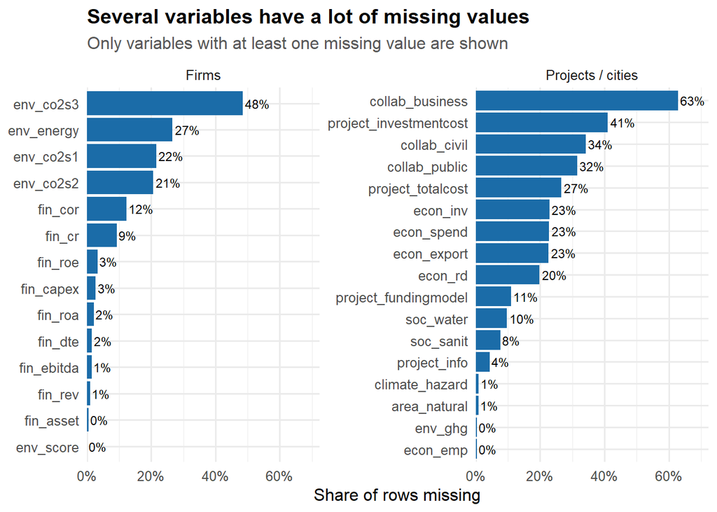

```r
miss_tbl <- bind_rows(
  projects_raw |> summarise(across(everything(), ~ mean(is.na(.x)))) |>
    pivot_longer(everything(), names_to = "variable", values_to = "pct_missing") |>
    mutate(dataset = "Projects / cities"),
  firms_raw |> summarise(across(everything(), ~ mean(is.na(.x)))) |>
    pivot_longer(everything(), names_to = "variable", values_to = "pct_missing") |>
    mutate(dataset = "Firms")
) |>
  filter(pct_missing > 0)

ggplot(miss_tbl, aes(x = pct_missing, y = reorder(variable, pct_missing))) +
  geom_col(fill = col_main) +
  geom_text(aes(label = percent(pct_missing, accuracy = 1)), hjust = -0.1, size = 3) +
  scale_x_continuous(labels = percent, expand = expansion(mult = c(0, 0.15))) +
  facet_wrap(~ dataset, scales = "free_y") +
  labs(title = "Several variables have a lot of missing values",
       subtitle = "Only variables with at least one missing value are shown",
       x = "Share of rows missing", y = NULL)
```

**Findings:** Missingness is heavy in the collaboration flags (`collab_business` is missing for about 63% of rows), in project costs, and in firm emissions (`env_co2s3` is missing for about half of firms). Missing collaboration flags are probably “not reported” rather than “No”, so I treat only `collab_business == 1` as *confirmed* experience. In the firm data, missing emissions mostly means the firm does not disclose them, so later I will keep a “was missing” indicator when I build the model. There are a few exact duplicate project rows, which I remove.

## 2.6 Cleaning the project data

Steps and reasons:

1. `distinct()` removes exact duplicate rows so projects are not double counted.
2. The text columns contain leftover escape codes such as `\n` and `\uXXXX` from the raw survey export, so I write a small cleaning function with `stringr` and `stringi`.
3. The project description starts with a project type, so I extract it with a regular expression. This is data extraction from text.

```r
clean_text <- function(x) {
  x |>
    str_replace_all("\\\\+n", " ") |>  # literal "\n" characters -> space
    stringi::stri_unescape_unicode() |> # turn "\u00a3" style codes into real symbols
    str_squish()
}

projects <- projects_raw |>
  distinct() |>
  mutate(across(c(cityname, climate_hazard, project_info, project_fundingmodel), clean_text),
         project_type = str_squish(str_extract(project_info, "^[^-:]+")),
         area_natural = na_if(area_natural, "I do not have this data"))

cat("Rows after removing duplicates:", nrow(projects), "\n")
```

```
## Rows after removing duplicates: 2586
```

```r
projects |>
  count(project_type, sort = TRUE) |>
  head(8) |>
  kable(caption = "Most common project types (first words of project_info)")
```

Most common project types (first words of project_info)

| project_type | n |
| --- | --- |
| Transport | 358 |
| Renewable energy | 333 |
| Other | 313 |
| Waste management (including waste recycling) | 290 |
| Buildings | 236 |
| Energy efficiency (including public lighting) | 227 |
| Water management | 208 |
| Public and green spaces | 192 |

## 2.7 Is the city information constant within a city?

The climate hazard text and the economic indicators are repeated on every project row of a city. I check that each city has exactly one value so that I can safely collapse to one row per city.

```r
const_check <- projects |>
  group_by(cityid) |>
  summarise(across(c(cityname, cityarea, cityregion, area_population, econ_gdpt, econ_gdtg,soc_water, climate_hazard), n_distinct)) |>
  summarise(across(-cityid, max))

const_check
```

| cityname | cityarea | cityregion | area_population | econ_gdpt | econ_gdtg | soc_water | climate_hazard |
| --- | --- | --- | --- | --- | --- | --- | --- |
| 1 | 1 | 1 | 1 | 1 | 1 | 1 | 1 |

```r
cities <- projects |>
  select(cityid, cityname, cityarea, cityregion, area_km, area_natural, area_population,
         starts_with("econ_"), env_ghg, starts_with("soc_"), climate_hazard,
         starts_with("collab_")) |>
  distinct(cityid, .keep_all = TRUE)

cat("Unique cities:", nrow(cities), "\n")
```

```
## Unique cities: 684
```

**Findings:** every value is `1`, so the city-level fields are indeed constant within a city. I now have a city table (`cities`, 684 rows) for the hazard analysis and a project table (`projects`) for the funding analysis.

## 2.8 Cleaning the firm data

```r
firms <- firms_raw |>
  mutate(env_contro = factor(env_contro, levels = c(1, 0), labels = c("Yes", "No")))

# the outcome: "Yes" is listed first so that tidymodels treats "Yes" as the event of interest

table(firms$env_contro)
```

```
##
##  Yes   No
##  206 7069
```

```r
prop.table(table(firms$env_contro))
```

```
##
##        Yes         No
## 0.02831615 0.97168385
```

**Findings:** only about 2.8% of firms have an environmental controversy. This is a strongly imbalanced outcome, which will shape how I build and judge the model in Part 4 (accuracy would be a misleading metric).

# 3 Part 1: Most common climate hazards affecting communities

The column `climate_hazard` is free text. For each city it contains several hazards written like `Hazard name: description | Hazard name: description ...`. To answer “which hazards are most common”, I need to extract the hazard names from the text and then count how many *cities* report each hazard. Then I look at the descriptions with text analysis to see *how* communities are affected, I test whether differences between regions are statistically real, and finally I use PCA and clustering to see whether groups of similar cities face different hazards.

## 3.1 City profile

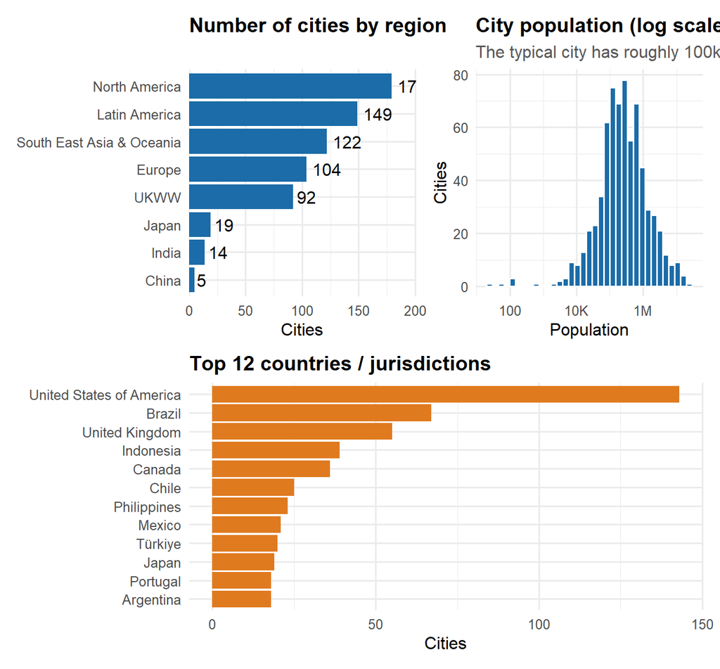

```r
p1 <- cities |>
  count(cityregion) |>
  ggplot(aes(x = n, y = reorder(cityregion, n))) +
  geom_col(fill = col_main) +
  geom_text(aes(label = n), hjust = -0.2) +
  scale_x_continuous(expand = expansion(mult = c(0, 0.12))) +
  labs(title = "Number of cities by region", x = "Cities", y = NULL)

p2 <- cities |>
  ggplot(aes(x = area_population)) +
  geom_histogram(bins = 35, fill = col_main, colour = "white") +
  scale_x_log10(labels = label_number(scale_cut = cut_short_scale())) +
  labs(title = "City population (log scale)",
       subtitle = "The typical city has roughly 100k to 700k people; a few are very large",
       x = "Population", y = "Cities")

p3 <- cities |>
  count(cityarea, sort = TRUE) |>
  slice_head(n = 12) |>
  ggplot(aes(x = n, y = reorder(cityarea, n))) +
  geom_col(fill = col_accent) +
  labs(title = "Top 12 countries / jurisdictions", x = "Cities", y = NULL)

(p1 | p2) / p3
```

**Findings:** the data are global but not evenly spread. North America, Latin America, Europe and “UKWW” (the label used in the dataset, mostly UK, South Africa and Türkiye) dominate, while India, Japan and China have only a handful of cities each. So conclusions about those three regions will be weak. The United States, Brazil and the United Kingdom supply the largest number of cities. I used a log scale for population because city size is very right-skewed.

## 3.2 Extracting the hazard names from the text

My steps:

1. Split each city’s text on the separator `|`.
2. Keep the words before the first colon as the hazard name.
3. A few descriptions themselves contain `|` or colons, which would create false “hazard names”. To avoid this I keep only names that appear in the official list of hazards used in the survey. I build the list from names that occur often (at least 4 cities) and are short.
4. Merge spelling variants (for example “urban flooding” and “Urban flooding”).

```r
hazard_segments <- cities |>
  filter(!is.na(climate_hazard)) |>
  mutate(segment = str_split(climate_hazard, "\\s\\|\\s")) |>
  unnest(segment) |>
  mutate(hazard_raw = str_squish(str_extract(segment, "^[^:]+")),
         hazard_raw = str_to_sentence(hazard_raw),
         hazard_raw = recode(hazard_raw, "Infectious diseases" = "Infectious disease"))

valid_hazards <- hazard_segments |>
  count(hazard_raw) |>
  filter(n >= 4, nchar(hazard_raw) < 70) |>
  pull(hazard_raw)

hazards <- hazard_segments |>
  filter(hazard_raw %in% valid_hazards) |>
  mutate(description = str_squish(str_remove(segment, "^[^:]+:"))) |>
  # a city could list the same hazard twice, so keep one row per city and hazard
  distinct(cityid, hazard_raw, .keep_all = TRUE) |>
  rename(hazard = hazard_raw)

cat("Number of hazard types found:", n_distinct(hazards$hazard), "\n")
```

```
## Number of hazard types found: 24
```

```r
cat("City-hazard records:", nrow(hazards), "from", n_distinct(hazards$cityid), "cities\n")
```

```
## City-hazard records: 3294 from 675 cities
```

I also group the detailed hazards into broader families. I do this because some hazards describe the same real-world problem (for example heat stress and extreme heat), and managers think in families.

```r
hazard_family <- tribble(
  ~hazard,                                                      ~family,
  "Extreme heat",                                               "Heat",
  "Heat stress",                                                "Heat",
  "Urban flooding",                                             "Flooding and heavy rain",
  "River flooding",                                             "Flooding and heavy rain",
  "Coastal flooding (incl. sea level rise)",                    "Flooding and heavy rain",
  "Heavy precipitation",                                        "Flooding and heavy rain",
  "Drought",                                                    "Drought and water scarcity",
  "Water stress",                                               "Drought and water scarcity",
  "Increased water demand",                                     "Drought and water scarcity",
  "Fire weather (risk of wildfires)",                           "Wildfire",
  "Storm",                                                      "Storms and wind",
  "Extreme wind",                                               "Storms and wind",
  "Hurricanes, cyclones, and/or typhoons",                      "Storms and wind",
  "Extreme cold",                                               "Cold, snow and ice",
  "Snow and ice",                                               "Cold, snow and ice",
  "Infectious disease",                                         "Health",
  "Mass movement",                                              "Land and ecosystems",
  "Soil degradation/erosion",                                   "Land and ecosystems",
  "Biodiversity loss",                                          "Land and ecosystems",
  "Loss of green space/green cover",                            "Land and ecosystems",
  "Other forms of climate-induced landscape shift/degradation", "Land and ecosystems",
  "Other coastal events",                                       "Other",
  "Oceanic events",                                             "Other",
  "Other",                                                      "Other"
)

hazards <- hazards |>
  left_join(hazard_family, by = "hazard") |>
  mutate(family = replace_na(family, "Other"))

# check that no valid hazard was left without a family
setdiff(unique(hazards$hazard), hazard_family$hazard)
```

```
## character(0)
```

## 3.3 The most common hazards

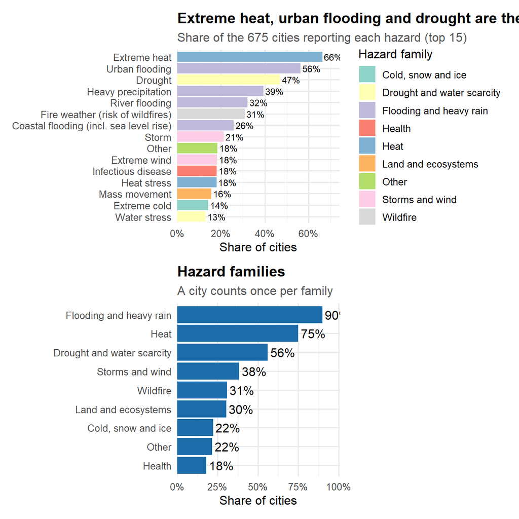

```r
n_cities_with_text <- n_distinct(hazards$cityid)

hazard_counts <- hazards |>
  count(hazard, family, sort = TRUE) |>
  mutate(pct = n / n_cities_with_text)

family_counts <- hazards |>
  distinct(cityid, family) |>      # a city counts once per family
  count(family, sort = TRUE) |>
  mutate(pct = n / n_cities_with_text)

h1 <- ggplot(hazard_counts |> slice_head(n = 15),
             aes(x = pct, y = reorder(hazard, pct), fill = family)) +
  geom_col() +
  geom_text(aes(label = percent(pct, accuracy = 1)), hjust = -0.1, size = 3.2) +
  scale_x_continuous(labels = percent, expand = expansion(mult = c(0, 0.12))) +
  scale_fill_brewer(palette = "Set3") +
  labs(title = "Extreme heat, urban flooding and drought are the most reported hazards",
       subtitle = paste0("Share of the ", n_cities_with_text, " cities reporting each hazard (top 15)"),
       x = "Share of cities", y = NULL, fill = "Hazard family")

h2 <- ggplot(family_counts, aes(x = pct, y = reorder(family, pct))) +
  geom_col(fill = col_main) +
  geom_text(aes(label = percent(pct, accuracy = 1)), hjust = -0.1) +
  scale_x_continuous(labels = percent, expand = expansion(mult = c(0, 0.12))) +
  labs(title = "Hazard families", subtitle = "A city counts once per family",
       x = "Share of cities", y = NULL)

wrap_plots(h1, h2, ncol = 1)
```

```r
hazard_counts |>
  slice_head(n = 10) |>
  mutate(pct = percent(pct, accuracy = 0.1)) |>
  rename(`Hazard` = hazard, `Family` = family, `Cities` = n, `% of cities` = pct) |>
  kable(caption = "Top 10 hazards by number of cities reporting them")
```

Top 10 hazards by number of cities reporting them

| Hazard | Family | Cities | % of cities |
| --- | --- | --- | --- |
| Extreme heat | Heat | 447 | 66.2% |
| Urban flooding | Flooding and heavy rain | 380 | 56.3% |
| Drought | Drought and water scarcity | 317 | 47.0% |
| Heavy precipitation | Flooding and heavy rain | 266 | 39.4% |
| River flooding | Flooding and heavy rain | 217 | 32.1% |
| Fire weather (risk of wildfires) | Wildfire | 208 | 30.8% |
| Coastal flooding (incl. sea level rise) | Flooding and heavy rain | 174 | 25.8% |
| Storm | Storms and wind | 143 | 21.2% |
| Other | Other | 124 | 18.4% |
| Extreme wind | Storms and wind | 123 | 18.2% |

[figure not shown]

```r
top10_tbl <- hazard_counts |> slice_head(n = 10)

# 1. Lollipop chart: number of cities per hazard
g1 <- ggplot(top10_tbl, aes(x = n, y = reorder(hazard, n), colour = family)) +
  geom_segment(aes(x = 0, xend = n, yend = reorder(hazard, n)), linewidth = 1) +
  geom_point(size = 4) +
  geom_text(aes(label = n), hjust = -0.6, colour = "black", size = 3.3) +
  scale_x_continuous(expand = expansion(mult = c(0, 0.15))) +
  scale_colour_brewer(palette = "Set3") +
  labs(title = "Top 10 hazards: number of cities reporting each",
       x = "Cities", y = NULL, colour = "Family")

# 2. Percentage of cities, coloured by family
g2 <- ggplot(top10_tbl, aes(x = pct, y = reorder(hazard, pct), fill = family)) +
  geom_col() +
  geom_text(aes(label = percent(pct, accuracy = 0.1)), hjust = -0.1, size = 3.3) +
  scale_x_continuous(labels = percent, expand = expansion(mult = c(0, 0.15))) +
  scale_fill_brewer(palette = "Set3") +
  labs(title = "Top 10 hazards: share of cities",
       x = "% of cities", y = NULL, fill = "Family")

# 3. How much of the top 10 comes from each family
g3 <- top10_tbl |>
  group_by(family) |>
  summarise(cities = sum(n), hazards = n(), .groups = "drop") |>
  ggplot(aes(x = cities, y = reorder(family, cities), fill = family)) +
  geom_col(show.legend = FALSE) +
  geom_text(aes(label = paste0(cities, " (", hazards, " hazards)")), hjust = -0.05, size = 3.3) +
  scale_x_continuous(expand = expansion(mult = c(0, 0.3))) +
  scale_fill_brewer(palette = "Set3") +
  labs(title = "Top 10 hazards grouped by family",
       subtitle = "A city can be counted in more than one hazard, so totals overlap",
       x = "City-hazard reports", y = NULL)

wrap_plots(wrap_plots(g1, g2, nrow = 1), g3, ncol = 1)
```

**Findings:** the top three individual hazards are extreme heat, urban flooding and drought. When I group hazards into families, flooding and heavy rain is the broadest problem (about nine in ten cities mention at least one flood-type hazard), followed by heat (about three in four cities) and drought / water scarcity (a little over half). This tells me that the climate risks to communities are mainly about too much water, too little water and too much heat. These are the threats that infrastructure such as drainage, wastewater, waste and water systems, and cooling or green space projects must address.

## 3.4 How many hazards does a city report?

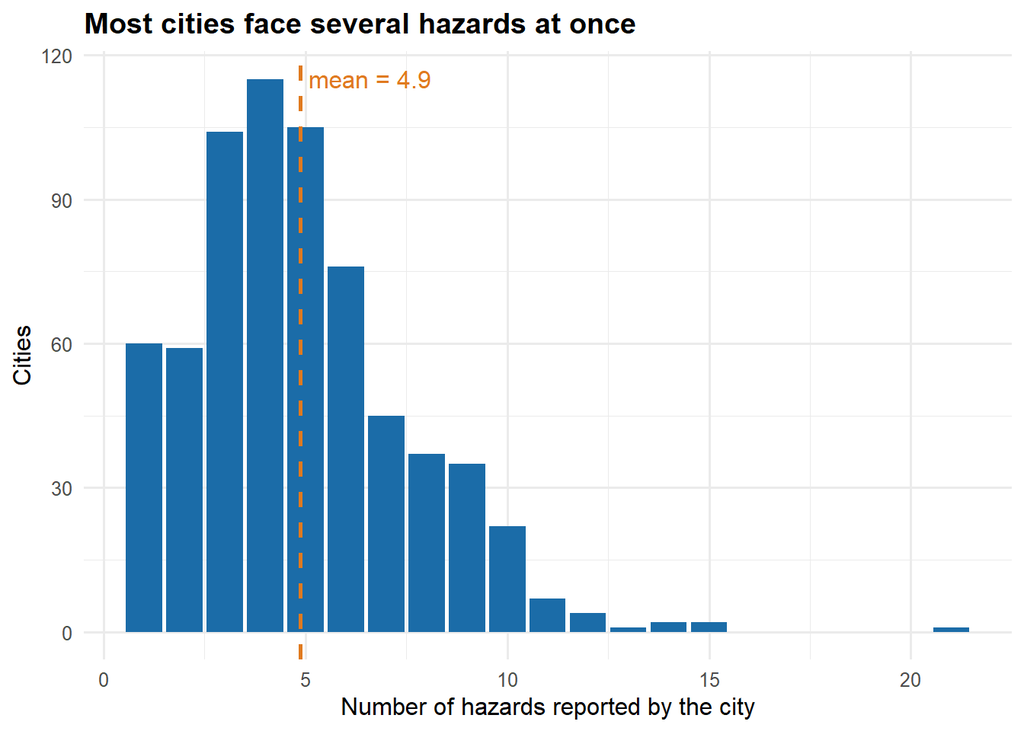

```r
hazards_per_city <- hazards |> count(cityid, name = "n_hazards")

ggplot(hazards_per_city, aes(x = n_hazards)) +
  geom_bar(fill = col_main) +
  geom_vline(xintercept = mean(hazards_per_city$n_hazards), colour = col_accent, linewidth = 1, linetype = "dashed") +
  annotate("text", x = mean(hazards_per_city$n_hazards) + 0.2, y = Inf, vjust = 2, hjust = 0,
           label = paste0("mean = ", round(mean(hazards_per_city$n_hazards), 1)), colour = col_accent) +
  labs(title = "Most cities face several hazards at once",
       x = "Number of hazards reported by the city", y = "Cities")
```

**Findings:** A typical city reports about five hazards, so risks are compound. For investors this means a single project (for example nature-based flood protection) can have several benefits.

## 3.5 Hazards by region

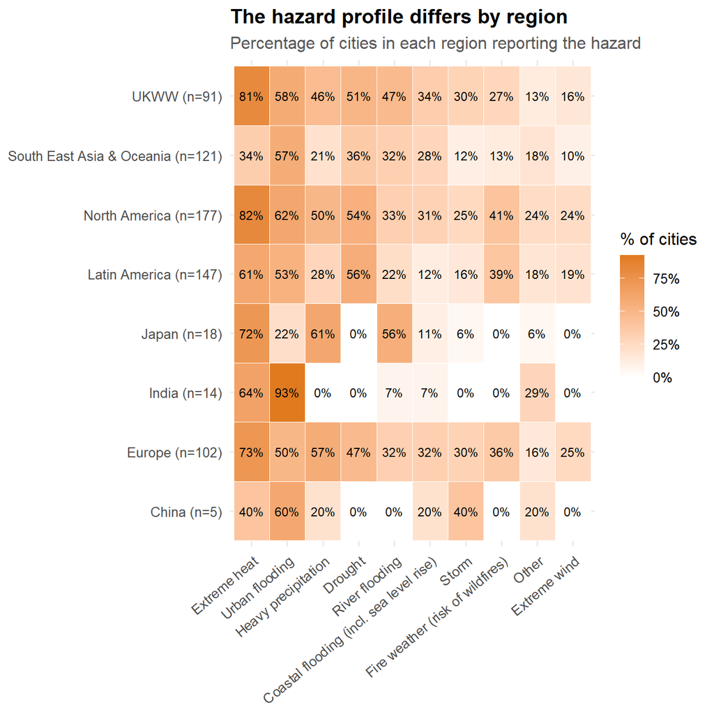

```r
region_n <- cities |> filter(!is.na(climate_hazard)) |> count(cityregion, name = "n_region")

top10 <- hazard_counts$hazard[1:10]

region_hazard <- hazards |>
  filter(hazard %in% top10) |>
  count(cityregion, hazard) |>
  right_join(expand_grid(cityregion = region_n$cityregion, hazard = top10), by = c("cityregion", "hazard")) |>
  mutate(n = replace_na(n, 0)) |>
  left_join(region_n, by = "cityregion") |>
  mutate(pct = n / n_region,
         region_label = paste0(cityregion, " (n=", n_region, ")"))

ggplot(region_hazard, aes(x = reorder(hazard, -pct, FUN = mean), y = region_label, fill = pct)) +
  geom_tile(colour = "white") +
  geom_text(aes(label = percent(pct, accuracy = 1)), size = 3) +
  scale_fill_gradient(low = "white", high = col_accent, labels = percent) +
  scale_x_discrete(guide = guide_axis(angle = 40)) +
  labs(title = "The hazard profile differs by region",
       subtitle = "Percentage of cities in each region reporting the hazard",
       x = NULL, y = NULL, fill = "% of cities")
```

## 3.6 Text analysis of the hazard descriptions (how are communities affected?)

Counting names only tells which hazards occur. The descriptions tell who and what is affected. I use text-analysis tools from class.

### 3.6.1 Pre-processing and term frequency

Computers cannot read sentences, so I convert the text to a “tidy” table with one word per row (`unnest_tokens`), remove very common words (`stop_words`), and also remove survey words that appear everywhere but carry no meaning (for example “city” or “climate”). Then I count words.

```r
custom_stop <- tibble(word = c("city", "climate", "change", "hazard", "also", "will", "may", "can", "areas", "area", "due", "per", "cent", "year", "years", "include", "including", "increase", "increased", "impact", "impacts", "affect", "affected", "http", "https", "www", "com", "etc", "particularly"))

tokens <- hazards |>
  select(cityid, cityregion, hazard, family, description) |>
  unnest_tokens(word, description) |>
  filter(!str_detect(word, "^[0-9]+$"), str_length(word) > 2) |>
  anti_join(stop_words, by = "word") |>
  anti_join(custom_stop, by = "word")

cat("Number of word tokens after cleaning:", nrow(tokens), "\n")
```

```
## Number of word tokens after cleaning: 206255
```

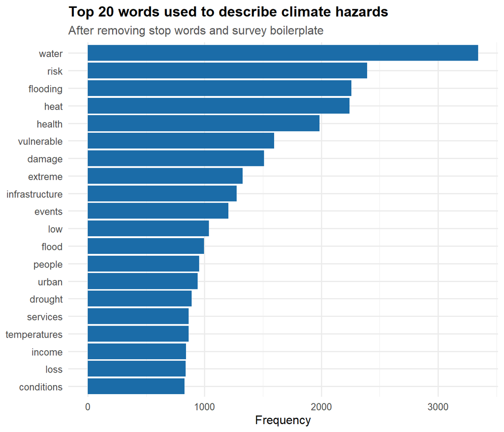

```r
tokens |>
  count(word, sort = TRUE) |>
  slice_head(n = 20) |>
  ggplot(aes(x = n, y = reorder(word, n))) +
  geom_col(fill = col_main) +
  labs(title = "Top 20 words used to describe climate hazards",
       subtitle = "After removing stop words and survey boilerplate",
       x = "Frequency", y = NULL)
```

**Findings:** the most frequent words relate to **water, heat, health, flooding, vulnerable groups and infrastructure**. This agrees with the hazard counts. Words such as “health”, “vulnerable”, “low” and “income” show that the descriptions repeatedly talk about vulnerable people, especially low-income households, which is the social side of the risk.

### 3.6.2 Word pairs (bigrams)

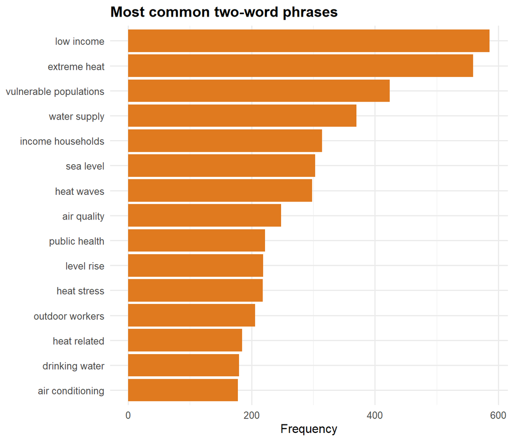

```r
bigrams <- hazards |>
  select(cityid, description) |>
  unnest_tokens(bigram, description, token = "ngrams", n = 2) |>
  filter(!is.na(bigram)) |>
  separate(bigram, c("w1", "w2"), sep = " ") |>
  filter(!w1 %in% c(stop_words$word, custom_stop$word),
         !w2 %in% c(stop_words$word, custom_stop$word),
         !str_detect(w1, "[0-9]"), !str_detect(w2, "[0-9]")) |>
  unite(bigram, w1, w2, sep = " ")

bigrams |>
  count(bigram, sort = TRUE) |>
  slice_head(n = 15) |>
  ggplot(aes(x = n, y = reorder(bigram, n))) +
  geom_col(fill = col_accent) +
  labs(title = "Most common two-word phrases", x = "Frequency", y = NULL)
```

**Findings:** Phrases give more context than single words. The most frequent pairs are “low income”, “extreme heat”, “vulnerable populations”, “water supply”, “heat waves” and “sea level” (rise). They show the mechanisms (heat waves, sea level rise, air quality) and the groups at risk (low-income households, outdoor workers), which helps connect hazards with infrastructure solutions.

### 3.6.3 Three Words (trigrams)

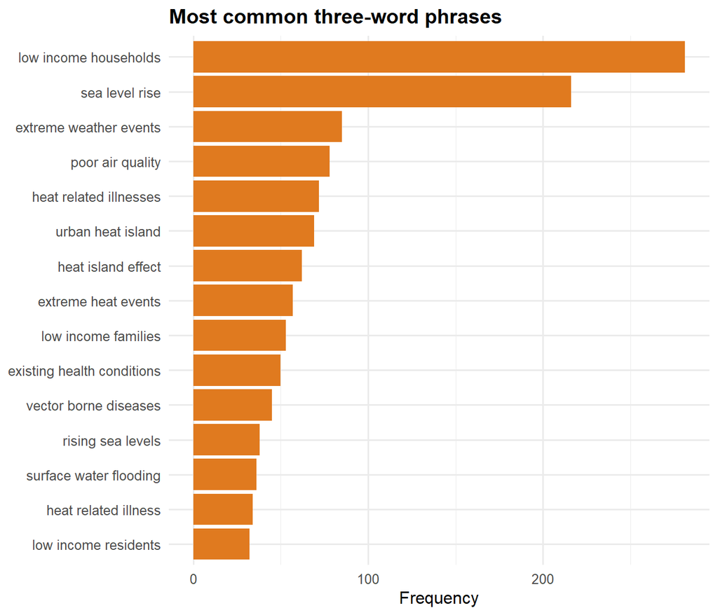

```r
trigrams <- hazards |>
  select(cityid, description) |>
  unnest_tokens(trigram, description, token = "ngrams", n = 3) |>
  filter(!is.na(trigram)) |>
  separate(trigram, c("w1", "w2", "w3"), sep = " ") |>
  filter(!w1 %in% c(stop_words$word, custom_stop$word),
         !w2 %in% c(stop_words$word, custom_stop$word),
         !w3 %in% c(stop_words$word, custom_stop$word),
         !str_detect(w1, "[0-9]"),
         !str_detect(w2, "[0-9]"),
         !str_detect(w3, "[0-9]"))|>
  unite(trigram, w1, w2, w3, sep = " ")

trigrams |>
  count(trigram, sort = TRUE) |>
  slice_head(n = 15) |>
  ggplot(aes(x = n, y = reorder(trigram, n))) +
  geom_col(fill = col_accent) +
  labs(title = "Most common three-word phrases", x = "Frequency", y = NULL)
```

### 3.6.4 Four Words (quadgrams)

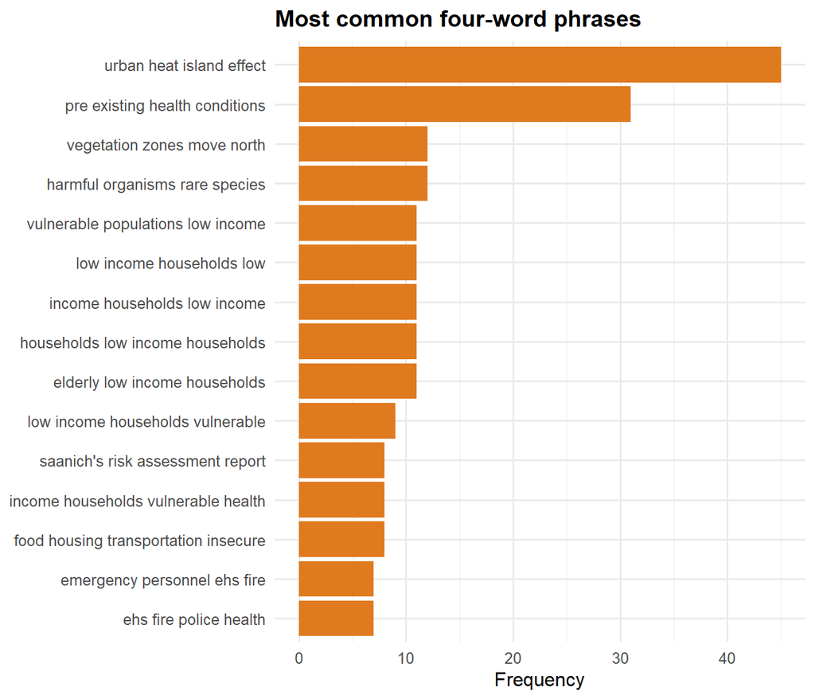

```r
quadgrams <- hazards |>
  select(cityid, description) |>
  unnest_tokens(quadgram, description, token = "ngrams", n = 4) |>
  filter(!is.na(quadgram)) |>
  separate(quadgram, c("w1", "w2", "w3", "w4"), sep = " ") |>
  filter(!w1 %in% c(stop_words$word, custom_stop$word),
         !w2 %in% c(stop_words$word, custom_stop$word),
         !w3 %in% c(stop_words$word, custom_stop$word),
         !w4 %in% c(stop_words$word, custom_stop$word),
         !str_detect(w1, "[0-9]"),
         !str_detect(w2, "[0-9]"),
         !str_detect(w3, "[0-9]"),
         !str_detect(w4, "[0-9]"))|>
  unite(quadgram, w1, w2, w3, w4, sep = " ")

quadgrams |>
  count(quadgram, sort = TRUE) |>
  slice_head(n = 15) |>
  ggplot(aes(x = n, y = reorder(quadgram, n))) +
  geom_col(fill = col_accent) +
  labs(title = "Most common four-word phrases", x = "Frequency", y = NULL)
```

**Findings:** The phrases contain income and heat in most frequently. It is apparent that the context squeezes if we increase number of words and sample size also decreases. Thus, in our case, its better to use bigram to understand the hazard descriptions efficiently.

### 3.6.5 Which words are special to each hazard family? (TF-IDF)

Plain word counts are dominated by common words. TF-IDF gives a high score to words that are frequent in one group but rare in the others, so it highlights what is *distinctive*.

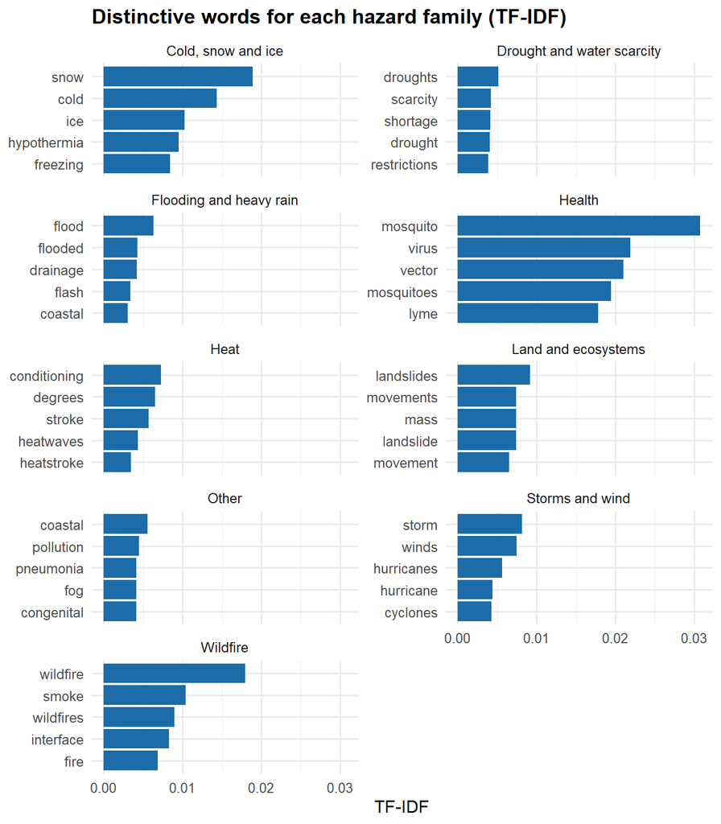

```r
tfidf_family <- tokens |>
  count(family, word) |>
  filter(n >= 5) |>
  bind_tf_idf(word, family, n) |>
  group_by(family) |>
  slice_max(tf_idf, n = 5, with_ties = FALSE) |>
  ungroup()

ggplot(tfidf_family, aes(x = tf_idf, y = reorder_within(word, tf_idf, family))) +
  geom_col(fill = col_main) +
  scale_y_reordered() +
  facet_wrap(~ family, scales = "free_y", ncol = 2) +
  labs(title = "Distinctive words for each hazard family (TF-IDF)",
       x = "TF-IDF", y = NULL)
```

### 3.6.6 Sentiment of the descriptions

I use the `bing` lexicon (positive vs negative words). Climate hazard descriptions are expected to be mostly negative; I want to see *which hazards sound the most negative*.

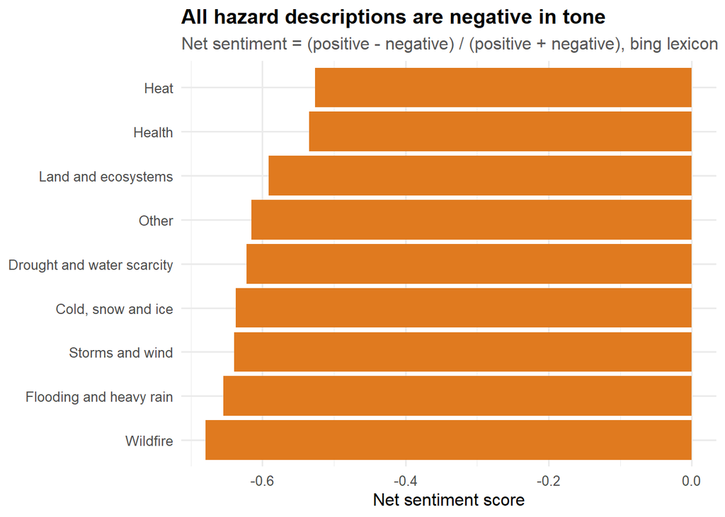

```r
sent <- tokens |>
  inner_join(get_sentiments("bing"), by = "word") |>
  count(family, sentiment) |>
  pivot_wider(names_from = sentiment, values_from = n, values_fill = 0) |>
  mutate(net_sentiment = (positive - negative) / (positive + negative))

ggplot(sent, aes(x = net_sentiment, y = reorder(family, net_sentiment))) +
  geom_col(fill = col_accent) +
  labs(title = "All hazard descriptions are negative in tone",
       subtitle = "Net sentiment = (positive - negative) / (positive + negative), bing lexicon",
       x = "Net sentiment score", y = NULL)
```

**Findings:** Every family has a clearly negative net score (roughly -0.5 to -0.7), as expected for descriptions of damage and vulnerability. Wildfire and flooding descriptions are the most negative, while heat and health are slightly less negative, possibly because those descriptions also mention support programmes and protective actions. A limitation I should mention: lexicon methods count words only and do not understand context (for example “protect” is positive even when talking about a risk).

### 3.6.7 Topic modelling (LDA)

To check what themes exist without telling the model the hazard names, I use Latent Dirichlet Allocation (LDA). I combine all descriptions for each city into one document, build a document-term matrix, and ask for 4 topics. The number of topics is a judgement call; 4 gives themes that are easy to interpret.

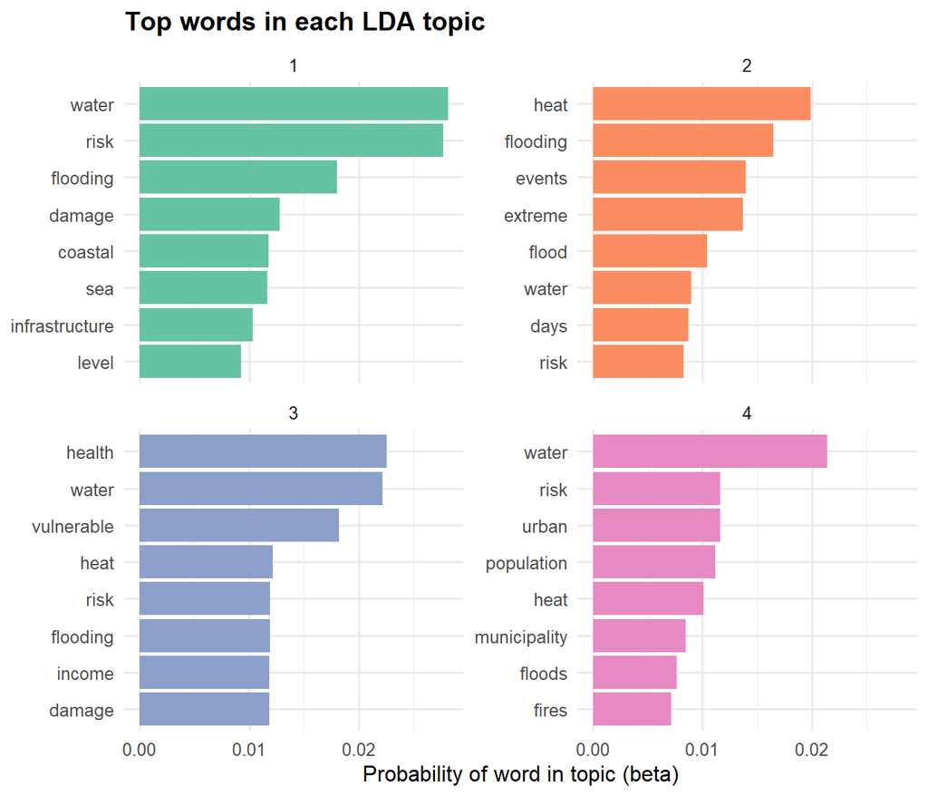

```r
dtm <- tokens |>
  count(cityid, word) |>
  group_by(word) |>
  filter(sum(n) >= 15) |>
  ungroup() |>   # drop very rare words
  cast_dtm(document = cityid, term = word, value = n)

# keep only documents with at least one term
dtm <- dtm[slam::row_sums(dtm) > 0, ]
lda_fit <- LDA(dtm, k = 4, control = list(seed = 123))

lda_terms <- tidy(lda_fit, matrix = "beta") |>
  group_by(topic) |>
  slice_max(beta, n = 8, with_ties = FALSE) |>
  ungroup()

ggplot(lda_terms, aes(x = beta, y = reorder_within(term, beta, topic), fill = factor(topic))) +
  geom_col(show.legend = FALSE) +
  scale_y_reordered() +
  scale_fill_brewer(palette = "Set2") +
  facet_wrap(~ topic, scales = "free_y") +
  labs(title = "Top words in each LDA topic", x = "Probability of word in topic (beta)", y = NULL)
```

## 3.7 Statistical inference and bivariate analysis

So far I have only described the sample. Here I ask whether the patterns are **statistically significant**. I use three tests and I check assumptions where relevant.

```r
# one row per city with 0/1 flags for the hazards I want to test
city_flags <- cities |>
  filter(!is.na(climate_hazard)) |>
  select(cityid, cityregion, area_population, econ_gdpt, soc_water, soc_sanit) |>
  left_join(hazards |>
              group_by(cityid) |>
              summarise(heat    = any(family == "Heat"),
                        flood   = any(family == "Flooding and heavy rain"),
                        drought = any(family == "Drought and water scarcity"),
                        n_haz   = n()), by = "cityid") |>
  mutate(across(c(heat, flood, drought), ~ replace_na(.x, FALSE)),
         n_haz = replace_na(n_haz, 0),
         log_pop = log10(area_population))
```

### 3.7.1 Confidence intervals for the share of cities reporting each hazard family

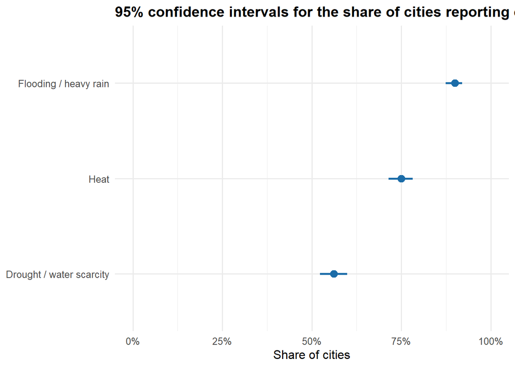

```r
ci_tbl <- city_flags |>
  summarise(across(c(heat, flood, drought), list(k = sum, n = length))) |>
  pivot_longer(everything(), names_to = c("family", ".value"), names_sep = "_") |>
  mutate(test = map2(k, n, ~ prop.test(.x, .y)),
         p = k / n,
         lower = map_dbl(test, ~ .x$conf.int[1]),
         upper = map_dbl(test, ~ .x$conf.int[2]),
         family = recode(family, heat = "Heat", flood = "Flooding / heavy rain", drought = "Drought / water scarcity"))

ggplot(ci_tbl, aes(x = p, y = reorder(family, p))) +
  geom_pointrange(aes(xmin = lower, xmax = upper), colour = col_main, linewidth = 1) +
  scale_x_continuous(labels = percent, limits = c(0, 1)) +
  labs(title = "95% confidence intervals for the share of cities reporting each hazard family",
       x = "Share of cities", y = NULL)
```

```r
ci_tbl |>
  transmute(family, `cities` = k, `share` = percent(p, accuracy = 0.1),`95% CI` = paste0(percent(lower, accuracy = 0.1), " to ", percent(upper, accuracy = 0.1))) |> kable()
```

| family | cities | share | 95% CI |
| --- | --- | --- | --- |
| Heat | 506 | 75.0% | 71.5% to 78.2% |
| Flooding / heavy rain | 607 | 89.9% | 87.3% to 92.0% |
| Drought / water scarcity | 379 | 56.1% | 52.3% to 59.9% |

**Findings:** The intervals are narrow because the sample has several hundred cities, so I can be fairly confident about how widespread each hazard family is among the cities in the CDP / ICLEI sample. (A caveat: these cities chose to report, so they may not represent all communities worldwide.)

### 3.7.2 Is extreme heat reporting related to region? (chi-squared test)

Both variables are categorical, so I use a chi-squared test of independence. Some regions have very few cities, so expected counts are small. To be safe I use a simulated p-value.

```r
tab_heat <- table(city_flags$cityregion, city_flags$heat)
tab_heat
```

```
##
##                             FALSE TRUE
##   China                         3    2
##   Europe                       10   92
##   India                         2   12
##   Japan                         4   14
##   Latin America                50   97
##   North America                16  161
##   South East Asia & Oceania    74   47
##   UKWW                         10   81
```

```r
chisq_heat <- chisq.test(tab_heat, simulate.p.value = TRUE, B = 5000)
chisq_heat
```

```
##
##  Pearson's Chi-squared test with simulated p-value (based on 5000
##  replicates)
##
## data:  tab_heat
## X-squared = 140.93, df = NA, p-value = 2e-04
```

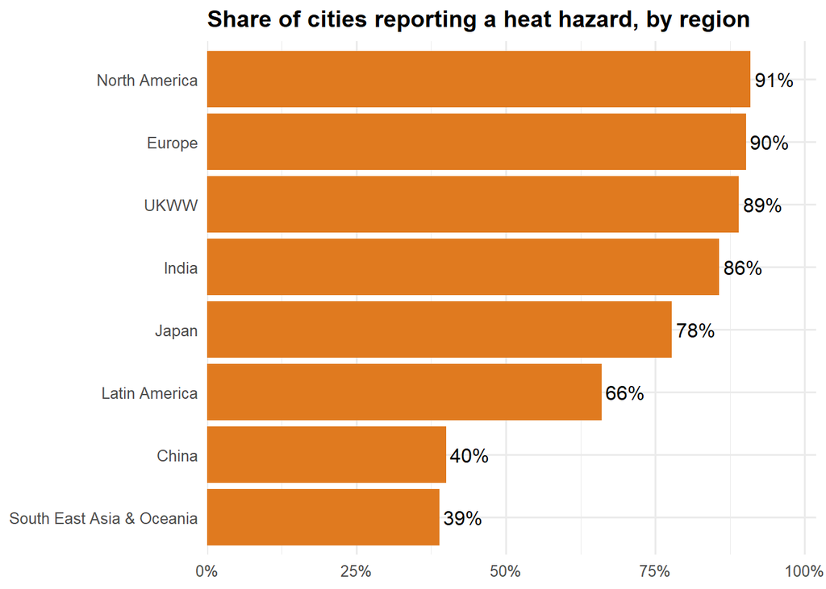

```r
city_flags |>
  group_by(cityregion) |>
  summarise(n = n(), pct_heat = mean(heat)) |>
  ggplot(aes(x = pct_heat, y = reorder(cityregion, pct_heat))) +
  geom_col(fill = col_accent) +
  geom_text(aes(label = percent(pct_heat, accuracy = 1)), hjust = -0.1) +
  scale_x_continuous(labels = percent, expand = expansion(mult = c(0, 0.12))) +
  labs(title = "Share of cities reporting a heat hazard, by region", x = NULL, y = NULL)
```

**Findings:** The null hypothesis is that heat reporting is independent of region. The simulated p-value is 2e-04, which is far below 0.05, so I reject the null and conclude that heat reporting rates really differ across regions (very high in North America, Europe and UKWW, much lower in South East Asia & Oceania and China). This matters for investors because it suggests that regional strategies (not one global strategy) are needed. One caution: reporting rates may also reflect how thoroughly a city completed the survey, not only the true hazard.

### 3.7.3 Do cities reporting drought differ in water services? (t-test and Wilcoxon test)

Hypothesis: cities in countries with less safely managed drinking water may be more likely to report drought or water stress.

** I compare `soc_water` for cities that report a drought-family hazard against those that do not.

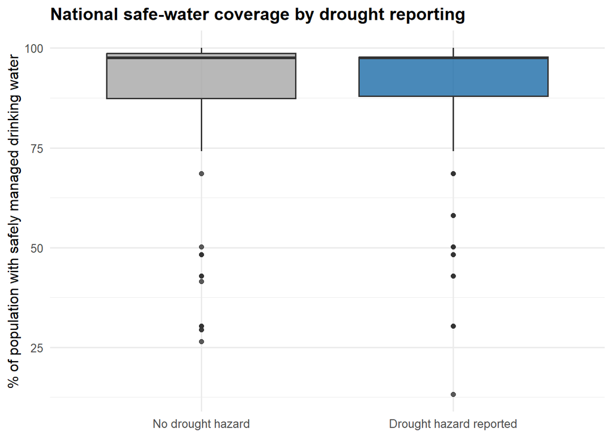

```r
water_df <- city_flags |> filter(!is.na(soc_water))

ggplot(water_df, aes(x = drought, y = soc_water, fill = drought)) +
  geom_boxplot(show.legend = FALSE, alpha = 0.8) +
  scale_fill_manual(values = c(col_grey, col_main)) +
  scale_x_discrete(labels = c("FALSE" = "No drought hazard", "TRUE" = "Drought hazard reported")) +
  labs(title = "National safe-water coverage by drought reporting",
       x = NULL, y = "% of population with safely managed drinking water")
```

```r
t_water <- t.test(soc_water ~ drought, data = water_df) # Welch t-test (does not assume equal variances)
w_water <- wilcox.test(soc_water ~ drought, data = water_df)  # non-parametric check (distribution is skewed)
t_water
```

```
##
##  Welch Two Sample t-test
##
## data:  soc_water by drought
## t = -0.47971, df = 559.89, p-value = 0.6316
## alternative hypothesis: true difference in means between group FALSE and group TRUE is not equal to 0
## 95 percent confidence interval:
##  -4.361335  2.649177
## sample estimates:
## mean in group FALSE  mean in group TRUE
##            85.42074            86.27682
```

```r
w_water
```

```
##
##  Wilcoxon rank sum test with continuity correction
##
## data:  soc_water by drought
## W = 42655, p-value = 0.3337
## alternative hypothesis: true location shift is not equal to 0
```

**Findings:** safe-water coverage is strongly left-skewed (many countries are near 100%), so the t-test assumption of normality is doubtful. That is why I also run the Wilcoxon test as a robustness check. Both tests give the same answer: the Welch t-test p-value is 0.63 and the Wilcoxon p-value is 0.33, and the two group means are very close (about 85.4% vs 86.3%). So my hypothesis was not supported: there is no evidence that cities reporting drought sit in countries with weaker water services. Drought and water scarcity affect cities in both well-served and poorly-served countries. For an investor this is a useful finding: water-resilience projects are relevant everywhere, not only in developing countries.

### 3.7.4 Do regions differ in the number of hazards? (ANOVA)

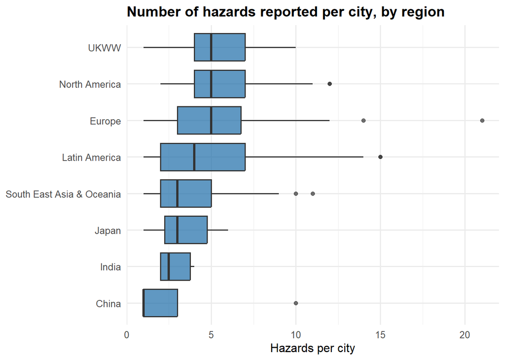

```r
ggplot(city_flags, aes(x = reorder(cityregion, n_haz, FUN = median), y = n_haz)) +
  geom_boxplot(fill = col_main, alpha = 0.7) +
  coord_flip() +
  labs(title = "Number of hazards reported per city, by region", x = NULL, y = "Hazards per city")
```

```r
aov_fit <- aov(n_haz ~ cityregion, data = city_flags)
summary(aov_fit)
```

```
##              Df Sum Sq Mean Sq F value   Pr(>F)
## cityregion    7    458   65.47   9.963 7.24e-12 ***
## Residuals   667   4383    6.57
## ---
## Signif. codes:  0 '***' 0.001 '**' 0.01 '*' 0.05 '.' 0.1 ' ' 1
```

```r
TukeyHSD(aov_fit)$cityregion |> as.data.frame() |> rownames_to_column("pair") |>
  filter(`p adj` < 0.05) |> arrange(`p adj`) |> head(8) |> kable(digits = 3, caption = "Region pairs with significantly different mean hazard counts (Tukey, top 8)")
```

Region pairs with significantly different mean hazard counts (Tukey, top 8)

| pair | diff | lwr | upr | p adj |
| --- | --- | --- | --- | --- |
| South East Asia & Oceania-North America | -1.981 | -2.901 | -1.062 | 0.000 |
| South East Asia & Oceania-Europe | -1.787 | -2.835 | -0.740 | 0.000 |
| UKWW-South East Asia & Oceania | 1.812 | 0.730 | 2.893 | 0.000 |
| South East Asia & Oceania-Latin America | -1.283 | -2.239 | -0.326 | 0.001 |
| North America-India | 2.791 | 0.627 | 4.954 | 0.002 |
| North America-Japan | 2.298 | 0.370 | 4.227 | 0.007 |
| UKWW-India | 2.621 | 0.383 | 4.859 | 0.009 |
| India-Europe | -2.597 | -4.818 | -0.375 | 0.010 |

```r
kruskal.test(n_haz ~ cityregion, data = city_flags)   # non-parametric equivalent
```

```
##
##  Kruskal-Wallis rank sum test
##
## data:  n_haz by cityregion
## Kruskal-Wallis chi-squared = 81.083, df = 7, p-value = 8.281e-15
```

**Findings:** ANOVA tests whether *at least one* region has a different average number of hazards, and Tukey’s test shows *which pairs* differ. The ANOVA p-value is extremely small, so the average number of hazards clearly differs between regions. North America, UKWW and Europe report the most hazards per city (roughly 5.4 to 5.6) while South East Asia & Oceania, Japan, China and India report fewer (roughly 2.8 to 3.6). Hazard counts are small integers and not normally distributed, so I confirm the result with the Kruskal-Wallis test, which agrees. The gap may partly reflect different reporting practices, not only different climate exposure.

### 3.7.5 Correlation between city indicators

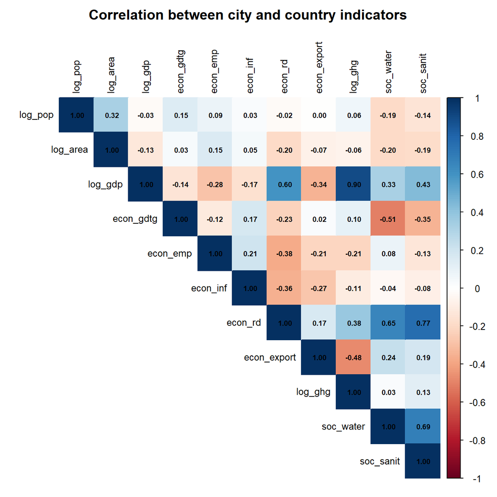

```r
corr_vars <- cities |>
  mutate(log_pop = log10(area_population), log_area = log10(area_km), log_gdp = log10(econ_gdpt),
         log_ghg = log10(env_ghg + 1)) |>
  select(log_pop, log_area, log_gdp, econ_gdtg, econ_emp, econ_inf, econ_rd, econ_export, log_ghg, soc_water, soc_sanit)

corrplot(cor(corr_vars, use = "pairwise.complete.obs"), method = "color", type = "upper",
         tl.col = "black", tl.cex = 0.8, addCoef.col = "black", number.cex = 0.6,
         title = "Correlation between city and country indicators", mar = c(0, 0, 2, 0))
```

**Findings:** National GDP and greenhouse gas emissions are very strongly correlated (about 0.9), which simply says that big economies emit more in total. R&D spending is strongly correlated with sanitation (about 0.77) and safe water (about 0.65), and safe water and sanitation are correlated with each other (about 0.69), so they all describe the national level of development. GDP growth is negatively correlated with safe water (about -0.5), which is typical of fast-growing emerging economies that still have service gaps. Highly correlated variables carry overlapping information, which is exactly why I use PCA next.

## 3.8 PCA and cluster analysis of cities

The city and country indicators are many and correlated. PCA compresses them into a few uncorrelated components, and clustering then groups cities with a similar socio-economic profile. I then check whether the clusters face different hazards.

I use log transforms for skewed variables, replace missing values with the median, scale all variables, and run `prcomp()`.

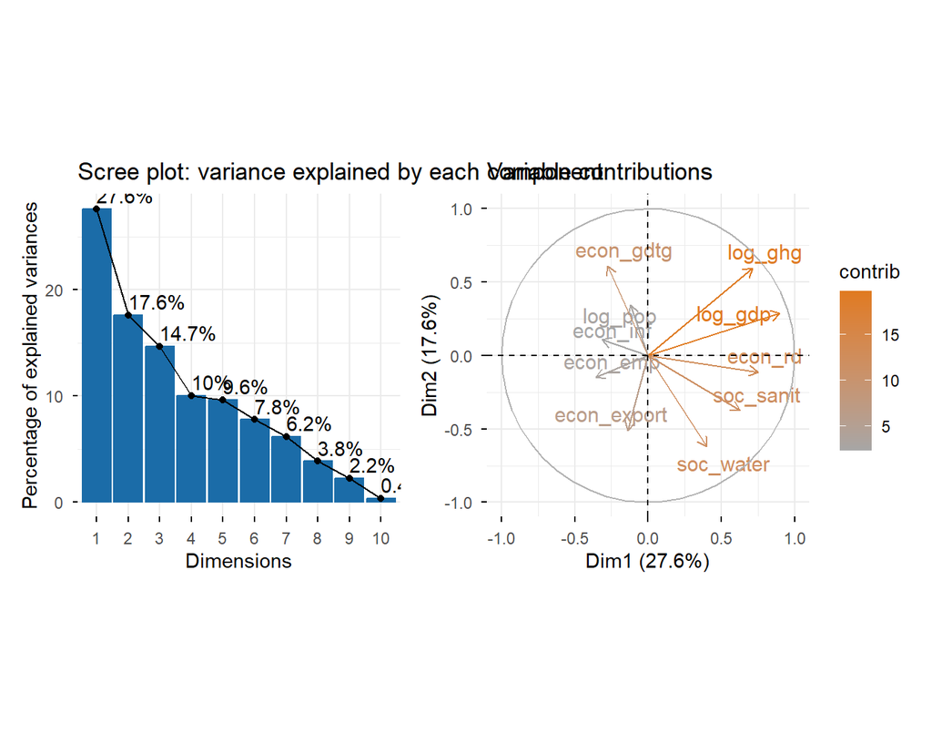

```r
pca_data <- cities |>
  transmute(cityid,
            log_pop = log10(area_population), log_gdp = log10(econ_gdpt), log_ghg = log10(env_ghg + 1),
            econ_gdtg, econ_emp, econ_inf, econ_rd, econ_export, soc_water, soc_sanit) |>
  mutate(across(-cityid, ~ replace_na(.x, median(.x, na.rm = TRUE))))

pca_city <- prcomp(select(pca_data, -cityid), scale. = TRUE)

(fviz_eig(pca_city, addlabels = TRUE, barfill = col_main, barcolor = col_main) +
    labs(title = "Scree plot: variance explained by each component")) |
  (fviz_pca_var(pca_city, col.var = "contrib", gradient.cols = c(col_grey, col_accent), repel = TRUE) +
     labs(title = "Variable contributions"))
```

```r
summary(pca_city)$importance[, 1:5] |> round(3) |> kable(caption = "Variance explained by the first five components")
```

Variance explained by the first five components

|  | PC1 | PC2 | PC3 | PC4 | PC5 |
| --- | --- | --- | --- | --- | --- |
| Standard deviation | 1.663 | 1.327 | 1.211 | 1.002 | 0.981 |
| Proportion of Variance | 0.276 | 0.176 | 0.147 | 0.100 | 0.096 |
| Cumulative Proportion | 0.276 | 0.453 | 0.599 | 0.700 | 0.796 |

**Findings:** The scree plot shows that no single component dominates: the first component explains roughly 28% of the variance, the first four about 70% and the first five about 80%. This tells me the indicators describe several different dimensions rather than one. In the variable plot, variables pointing in the same direction are positively correlated. The first component is mostly driven by national economic size and development (GDP, R&D spending, emissions and sanitation), so it separates large, more developed economies from the rest. The later components mix growth, unemployment, inflation and export dependence.

### 3.8.1 K-means clustering

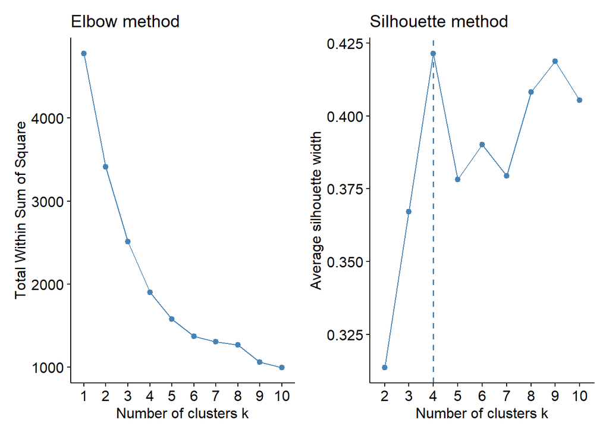

```r
scores <- as_tibble(pca_city$x[, 1:4])

(fviz_nbclust(scores, kmeans, method = "wss") + labs(title = "Elbow method")) |
  (fviz_nbclust(scores, kmeans, method = "silhouette") + labs(title = "Silhouette method"))
```

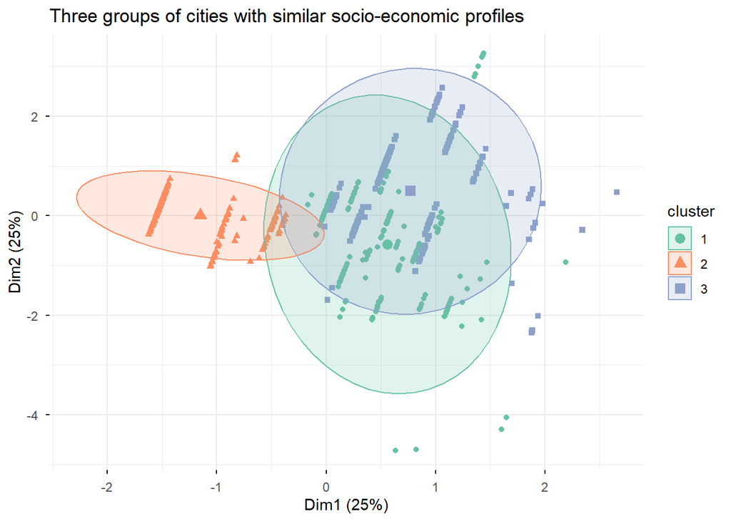

```r
km_city <- kmeans(scores, centers = 3, nstart = 25)

city_clusters <- pca_data |>
  mutate(cluster = factor(km_city$cluster)) |>
  left_join(select(cities, cityid, cityregion, area_population, econ_gdpt), by = "cityid")

fviz_cluster(km_city, data = scores, geom = "point", ellipse.type = "norm", palette = "Set2",
             ggtheme = theme_minimal()) +
  labs(title = "Three groups of cities with similar socio-economic profiles")
```

```r
city_clusters |>
  group_by(cluster) |>
  summarise(cities = n(),
            median_pop = median(area_population),
            median_gdp_bn = median(econ_gdpt) / 1e9,
            mean_water = mean(soc_water),
            mean_inflation = mean(econ_inf),
            top_region = names(which.max(table(cityregion)))) |>
  kable(digits = 1, caption = "Cluster profiles")
```

Cluster profiles

| cluster | cities | median_pop | median_gdp_bn | mean_water | mean_inflation | top_region |
| --- | --- | --- | --- | --- | --- | --- |
| 1 | 200 | 165613 | 530.8 | 95.5 | 3.0 | Europe |
| 2 | 252 | 203582 | 30769.7 | 98.3 | 3.0 | North America |
| 3 | 232 | 442184 | 1597.3 | 67.9 | 9.6 | Latin America |

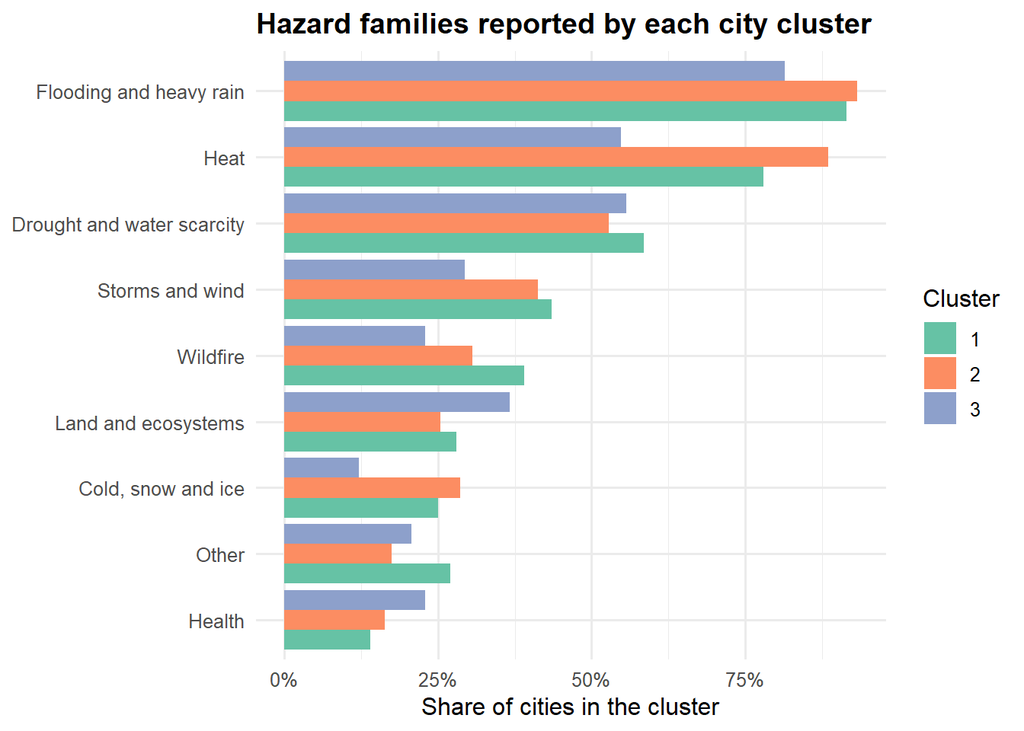

```r
# do the clusters face different hazards?
cluster_hazard <- hazards |>
  inner_join(select(city_clusters, cityid, cluster), by = "cityid") |>
  distinct(cityid, cluster, family) |>
  count(cluster, family) |>
  left_join(count(city_clusters, cluster, name = "n_cluster"), by = "cluster") |>
  mutate(pct = n / n_cluster)

ggplot(cluster_hazard, aes(x = pct, y = reorder(family, pct), fill = cluster)) +
  geom_col(position = "dodge") +
  scale_x_continuous(labels = percent) +
  scale_fill_brewer(palette = "Set2") +
  labs(title = "Hazard families reported by each city cluster",
       x = "Share of cities in the cluster", y = NULL, fill = "Cluster")
```

**Findings:** The three clusters differ mainly in economic size, water services and inflation. In my run one cluster is dominated by Latin American cities in emerging economies with the weakest safe-water coverage (about two thirds of the population) and the highest inflation; one is mostly European cities in smaller, high-service economies; and one is mostly North American cities in the largest economy. Flooding is reported by more than 80% of cities in every cluster, and drought is similarly common in all three (roughly 53% to 59%), which again shows that these are global problems and not limited to one type of economy. The emerging-economy cluster reports relatively more health and land-related hazards (such as landslides) but less heat, cold and wildfire than the other two.

## 3.9 Summary of main findings for Part 1

1. **Most common hazards.** Out of 675 cities, the three most reported single hazards are **Extreme heat** (66%), **Urban flooding** (56%) and **Drought** (47%).
2. **By family,** **Flooding and heavy rain** is the broadest problem (90% of cities), followed by heat and drought / water scarcity. The main climate risks are therefore *too much water, too little water and too much heat*.
3. **Compound risk.** The average city reports about 4.9 hazards, so projects that address several hazards at once (nature-based solutions, resilient water and waste systems) are attractive.
4. **Who is affected.** Text analysis shows that the descriptions focus on health, vulnerable and low-income households, outdoor workers, water supply and infrastructure damage. Sentiment is negative for every hazard family, and the LDA topics broadly match the hazard families.
5. **Regional differences are real, national water services are not the driver of drought.** The chi-squared, ANOVA and Kruskal-Wallis tests show that heat reporting and the number of hazards differ by region, so investment strategy should be adapted by region. In contrast, the t-test and Wilcoxon test found no link between drought reporting and national safe-water coverage.
6. **Limitations.** The data are self-reported by cities that chose to disclose, regions such as India, Japan and China have very few cities, and hazard names were extracted from free text.

# 4 Part 2: Planned projects and funding sought by region

My manager wants the **total number of planned projects** and the **total value of funding sought** for each region. The columns I use are:

- a **project** = one row of the project table that has at least some project information (rows where every project field is empty are cities that did not list a project, so I do not count them),
- **funding sought** = `project_investmentcost` (the “total investment cost needed”), because this is the amount a financier would be asked to provide. `project_totalcost` is the overall project cost and may include money that is already secured.

## 4.1 Checking the cost data before summing

Before adding up money, I always check for outliers, because a single data-entry error can ruin a total. I look at the largest values.

```r
projects <- projects |>
  mutate(is_project = !(is.na(project_info) & is.na(project_investmentcost) &
                          is.na(project_totalcost) & is.na(project_fundingmodel)),
         cost_to_gdp = project_investmentcost / econ_gdpt)

projects |>
  filter(!is.na(project_investmentcost)) |>
  arrange(desc(project_investmentcost)) |>
  transmute(city = cityname, region = cityregion,
            investment_cost_usd = project_investmentcost,
            national_gdp_usd = econ_gdpt,
            cost_as_multiple_of_gdp = cost_to_gdp) |>
  head(8) |>
  kable(format.args = list(big.mark = ",", scientific = FALSE, digits = 3),
        caption = "The eight largest investment costs in the data")
```

The eight largest investment costs in the data

| city | region | investment_cost_usd | national_gdp_usd | cost_as_multiple_of_gdp |
| --- | --- | --- | --- | --- |
| Cardiff Capital Region | UKWW | 3,692,521,866,750,161 | 4,002,587,541,846 | 922.53369 |
| Cardiff Capital Region | UKWW | 13,187,578,095,536 | 4,002,587,541,846 | 3.29476 |
| Santiago de Cali | Latin America | 5,350,128,747,568 | 457,410,034,203 | 11.69657 |
| Greater London Authority | UKWW | 138,469,570,003 | 4,002,587,541,846 | 0.03460 |
| Greater Manchester Combined Authority | UKWW | 84,400,499,811 | 4,002,587,541,846 | 0.02109 |
| West Midlands Combined Authority | UKWW | 39,562,734,287 | 4,002,587,541,846 | 0.00988 |
| City of Stockholm | Europe | 27,397,857,742 | 668,998,664,082 | 0.04095 |
| West Midlands Combined Authority | UKWW | 26,375,156,191 | 4,002,587,541,846 | 0.00659 |

**Findings:** The three largest values (about 3.7 quadrillion, 13 trillion and 5.4 trillion USD) are greater than the annual GDP of the country where the city is located. That is not realistic for a single city project, so I treat these as likely data-entry or currency errors (for example a local currency value typed in as USD). If I leave them in, they would swamp every other project and make the regional totals meaningless.

My cleaning rule is: *an investment cost larger than the national GDP is treated as an error and excluded from totals* (the project is still counted as a planned project). Other very large values, such as the multi-billion-dollar plans in London or Manchester, are below this limit and I keep them. I also check how many projects have an investment cost larger than the total cost, which is logically odd:

```r
projects <- projects |>
  mutate(cost_error = !is.na(cost_to_gdp) & cost_to_gdp > 1,
         investment_clean = if_else(cost_error, NA_real_, project_investmentcost),
         # stricter check: an investment cost larger than the project's own total cost is inconsistent
         inconsistent_cost = !is.na(project_investmentcost) & !is.na(project_totalcost) &
                               project_investmentcost > project_totalcost,
         investment_strict = if_else(cost_error | inconsistent_cost, NA_real_, project_investmentcost))

cat("Projects flagged as cost errors (cost > national GDP):", sum(projects$cost_error, na.rm = TRUE), "\n")
```

```
## Projects flagged as cost errors (cost > national GDP): 3
```

```r
cat("Projects where investment cost > total cost         :",
    sum(projects$project_investmentcost > projects$project_totalcost, na.rm = TRUE), "(kept in the main total, removed in the stricter total)\n")
```

```
## Projects where investment cost > total cost         : 129 (kept in the main total, removed in the stricter total)
```

```r
cat("Projects with a reported investment cost of zero     :",
    sum(projects$project_investmentcost == 0, na.rm = TRUE), "\n")
```

```
## Projects with a reported investment cost of zero     : 191
```

## 4.2 Totals by region

```r
region_summary <- projects |>
  filter(is_project) |>
  group_by(cityregion) |>
  summarise(planned_projects   = n(),
            projects_with_cost = sum(!is.na(investment_clean)),
            funding_raw_usd    = sum(project_investmentcost, na.rm = TRUE),
            funding_clean_usd  = sum(investment_clean, na.rm = TRUE),
            funding_strict_usd = sum(investment_strict, na.rm = TRUE),
            median_cost_usd    = median(investment_clean[investment_clean > 0], na.rm = TRUE),
            .groups = "drop") |>
  arrange(desc(funding_clean_usd))

region_total_row <- region_summary |>
  summarise(cityregion = "TOTAL", across(c(planned_projects, projects_with_cost, funding_raw_usd, funding_clean_usd, funding_strict_usd), sum),
            median_cost_usd = median(projects$investment_clean[projects$investment_clean > 0], na.rm = TRUE))

bind_rows(region_summary, region_total_row) |>
  mutate(funding_clean_bn = funding_clean_usd / 1e9,
         funding_strict_bn = funding_strict_usd / 1e9,
         funding_raw_bn   = funding_raw_usd / 1e9) |>
  select(Region = cityregion, `Planned projects` = planned_projects,
         `Projects with a cost` = projects_with_cost,
         `Funding sought, cleaned (USD bn)` = funding_clean_bn,
         `Funding, stricter rule (USD bn)` = funding_strict_bn,
         `Funding incl. outliers (USD bn)` = funding_raw_bn,
         `Median project cost (USD)` = median_cost_usd) |>
  kable(digits = 1, format.args = list(big.mark = ","),
        caption = "Number of planned projects and total investment cost sought, by region")
```

Number of planned projects and total investment cost sought, by region

| Region | Planned projects | Projects with a cost | Funding sought, cleaned (USD bn) | Funding, stricter rule (USD bn) | Funding incl. outliers (USD bn) | Median project cost (USD) |
| --- | --- | --- | --- | --- | --- | --- |
| UKWW | 457 | 318 | 323.9 | 157.0 | 3,706,033.3 | 1,318,757.8 |
| North America | 684 | 416 | 46.1 | 41.1 | 46.1 | 4,147,384.3 |
| Europe | 487 | 229 | 39.5 | 34.1 | 39.5 | 1,351,040.9 |
| South East Asia & Oceania | 276 | 211 | 7.2 | 7.0 | 7.2 | 1,073,679.3 |
| Latin America | 533 | 326 | 5.2 | 4.6 | 5,355.4 | 307,453.8 |
| India | 25 | 20 | 0.1 | 0.1 | 0.1 | 2,542,385.4 |
| Japan | 5 | 4 | 0.0 | 0.0 | 0.0 | 1,432,753.8 |
| China | 10 | 0 | 0.0 | 0.0 | 0.0 | NA |
| TOTAL | 2,477 | 1,524 | 422.0 | 244.1 | 3,711,481.6 | 1,300,000.0 |

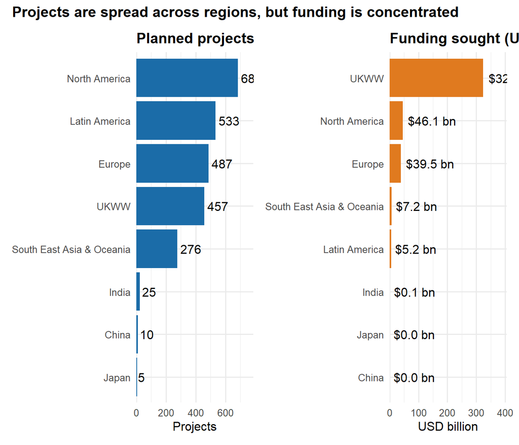

```r
r1 <- ggplot(region_summary, aes(x = planned_projects, y = reorder(cityregion, planned_projects))) +
  geom_col(fill = col_main) +
  geom_text(aes(label = comma(planned_projects)), hjust = -0.15) +
  scale_x_continuous(expand = expansion(mult = c(0, 0.15))) +
  labs(title = "Planned projects", x = "Projects", y = NULL)

r2 <- ggplot(region_summary, aes(x = funding_clean_usd / 1e9, y = reorder(cityregion, funding_clean_usd))) +
  geom_col(fill = col_accent) +
  geom_text(aes(label = paste0("$", comma(funding_clean_usd / 1e9, accuracy = 0.1), " bn")), hjust = -0.1) +
  scale_x_continuous(expand = expansion(mult = c(0, 0.25))) +
  labs(title = "Funding sought (USD bn, cleaned)", x = "USD billion", y = NULL)

r1 + r2 + plot_annotation(title = "Projects are spread across regions, but funding is concentrated")
```

**Findings:**

- In total there are **2,477 planned projects**, and 1,524 of them (about 62%) have a usable investment cost. After removing the 3 unrealistic values, the total funding sought is about **USD 422.0 billion**. With the outliers included it would have been about USD 3,711 trillion, which shows why the check was necessary.
- **Stricter check:** The values removed above are those larger than national GDP, but some remaining entries are also inconsistent: 129 projects state an investment cost larger than their own total cost (in some cases many times larger). If these are also excluded, the total funding sought falls from about USD 422.0 billion to about **USD 244.1 billion**, and **UKWW** is the largest region (about USD 157.0 billion). The main table keeps the original rule, so the manager should treat the “stricter rule” column as the more cautious estimate.
- **North America** has the most planned projects (684), while **UKWW** has the largest amount of funding sought (about USD 323.9 billion).
- The median project cost is much smaller than the average , so a few very large programs drive the totals. For planning, the median is a better guide to a typical project and the total is a better guide to the size of the overall market.
- Caution: about 38% of projects have no usable investment cost, so the true funding need is larger than these totals. Regions where many projects have no cost (compare “Planned projects” with “Projects with a cost”) are under-reported; for example none of the 10 Chinese projects has a usable cost (0 with a cost), so China shows zero funding even though it has planned projects.
- The funding total is very concentrated: UKWW alone makes up 77% of the cleaned total, mainly because of a few very large programmes such as those in the Greater London Authority and Greater Manchester. Planned *project counts* are much more evenly spread than *money*.

# 5 Part 3: Ranked list of collaboration and investment opportunities

## 5.1 Turning the scenario into selection rules

The scenario gives me four business criteria. I translate each into a filter in R:

1. Industry expertise in waste management: the city itself labels the project as “Waste management” (the project type at the start of `project_info`). I use this label as the main rule because keyword matching also catches broad multi-sector programmes that only mention “circular economy” or “waste” in passing. Projects outside the waste sector that merely contain waste-related words (waste, recycling, landfill, compost, circular economy and similar; excluding wastewater and “waste heat”) are not ranked; I show them in a separate manual-review list below.
2. Prefers partners who have collaborated with private for-profit organisations: `collab_business == 1` (confirmed past collaboration). Missing values are *not* treated as “yes”.
3. Track record of loans and public-private partnerships: for public sector projects `project_fundingmodel` contains “Loans” (commercial banks or international financial institutions) or “Public-private partnership”.
4. Needs a known investment cost to rank: `project_investmentcost` is available, above zero and not flagged as an error.

Then I rank the surviving projects in descending order of investment cost sought, as my manager asked.

## 5.2 Applying the filters

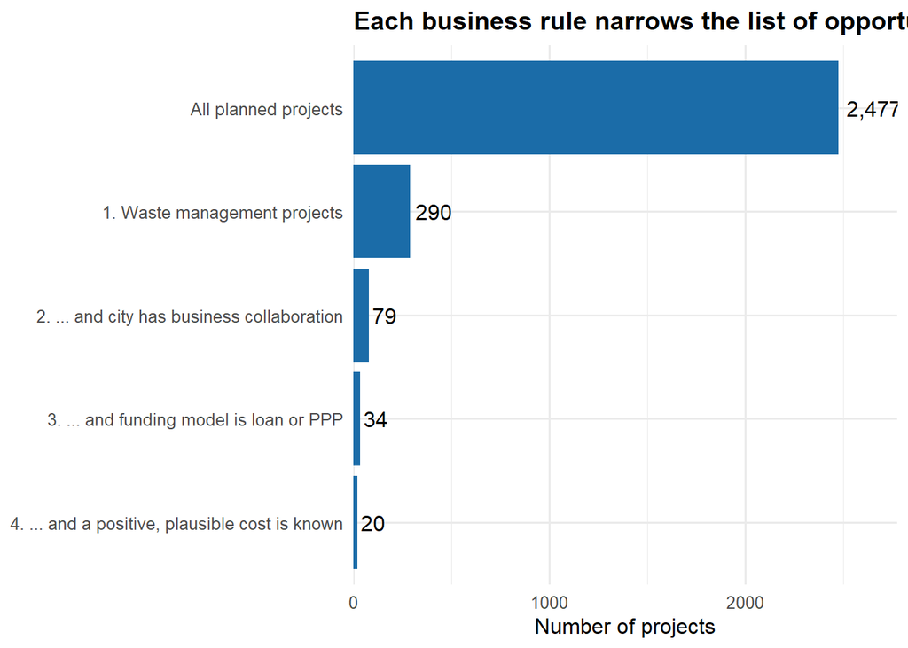

```r
waste_pattern <- "\\bwastes?\\b|recycl|landfill|compost|garbage|circular econom|incinerat|zero.waste"

projects <- projects |>
  mutate(info_lower = str_to_lower(project_info),
         waste_keyword = str_detect(info_lower, waste_pattern) &
           !str_detect(info_lower, "wastewater|waste water|waste heat|waste-water"),
         is_waste = (str_detect(project_type, "^Waste management") %in% TRUE),
         waste_keyword_only = waste_keyword & !is_waste,   # waste words, but not labelled as waste management
         business_collab = collab_business %in% 1,
         loan_or_ppp = str_detect(project_fundingmodel, "Loans|Public-private") %in% TRUE)

funnel <- tribble(
  ~step, ~projects,
  "All planned projects", sum(projects$is_project),
  "1. Waste management projects", sum(projects$is_project & projects$is_waste),
  "2. ... and city has business collaboration", sum(projects$is_project & projects$is_waste & projects$business_collab),
  "3. ... and funding model is loan or PPP",  sum(projects$is_project & projects$is_waste & projects$business_collab & projects$loan_or_ppp),
  "4. ... and a positive, plausible cost is known", sum(projects$is_project & projects$is_waste & projects$business_collab & projects$loan_or_ppp & (projects$investment_clean > 0) %in% TRUE)
)

ggplot(funnel, aes(x = projects, y = factor(step, levels = rev(step)))) +
  geom_col(fill = col_main) +
  geom_text(aes(label = comma(projects)), hjust = -0.15) +
  scale_x_continuous(expand = expansion(mult = c(0, 0.12))) +
  labs(title = "Each business rule narrows the list of opportunities",
       x = "Number of projects", y = NULL)
```

**Findings:** The funnel shows that the firm’s criteria are quite selective. Waste projects are common, but only a minority come from cities with confirmed private-sector collaboration and a loan or PPP funding model, and fewer still have a reported investment cost. In my run the funnel goes from 2,477 projects to 290 waste projects, 79 with business collaboration, 34 with a loan or PPP funding model and finally 20 with a usable cost. Because of this, the final list is short and highly targeted, which suits an investment firm that wants a manageable pipeline.

## 5.3 The ranked list

```r
ranked <- projects |>
  filter(is_project, is_waste, business_collab, loan_or_ppp, investment_clean > 0) |>
  arrange(desc(investment_clean)) |>
  mutate(Rank = row_number(),
         Project = str_trunc(str_squish(project_info), 120),
         `Funding model` = str_replace_all(project_fundingmodel, "\\|", ", ")) |>
  transmute(Rank, City = cityname, Country = cityarea, Region = cityregion, Project,
            `Funding model`,
            `Investment cost (USD)` = investment_clean,
            `Total cost (USD)` = project_totalcost,
            `Cost check` = if_else(!is.na(project_totalcost) & investment_clean > project_totalcost, "investment cost > total cost", "ok"))

kable(ranked, format.args = list(big.mark = ",", scientific = FALSE),
      caption = "Ranked list of waste-management projects with business collaboration and loan / PPP funding (descending investment cost)")
```

Ranked list of waste-management projects with business collaboration and loan / PPP funding (descending investment cost)

| Rank | City | Country | Region | Project | Funding model | Investment cost (USD) | Total cost (USD) | Cost check |
| --- | --- | --- | --- | --- | --- | --- | --- | --- |
| 1 | Municipality of Fortaleza | Brazil | Latin America | Waste management (including waste recycling) - Composting Plants: Installation of composting stations in institutions… | Loans from International Financial Institutions, Public finance- own budget, No financing model identified, Public-private partnership | 80,649,487.89 | 80,649.49 | investment cost > total cost |
| 2 | Seberang Perai Municipal Council | Malaysia | South East Asia & Oceania | Waste management (including waste recycling) - Waste Eco Park: Waste Eco Park is a sustainable approach to managing w… | Public-private partnership, Private investment, Carbon markets | 46,758,408.17 | 46,758,408.17 | ok |
| 3 | Thua Thien Hue Province | Viet Nam | South East Asia & Oceania | Waste management (including waste recycling) - Development of centralized wastewater collection and treatment systems… | Grants, Loans from International Financial Institutions, Public finance- own budget, Public finance- national government | 40,412,988.68 | 288,664,204.86 | ok |
| 4 | City of Buenos Aires | Argentina | Latin America | Waste management (including waste recycling) - Composting plant: A composting plant is proposed that uses static pile… | Loans from International Financial Institutions, Loans from commercial banks | 27,641,198.98 | 27,641,198.98 | ok |
| 5 | City of New Orleans, LA | United States of America | North America | Waste management (including waste recycling) - City MRF station construction: The City of New Orleans plans to increa… | Private investment, Public-private partnership, Bonds, Grants | 20,000,000.00 | 20,000,000.00 | ok |
| 6 | City of Buenos Aires | Argentina | Latin America | Waste management (including waste recycling) - Anaerobic Digestion Plant: Semi - Dry technology is proposed. The Semi… | Loans from commercial banks, Loans from International Financial Institutions | 19,348,839.28 | 19,348,839.28 | ok |
| 7 | Bhavnagar Municipal Corporation | India | India | Waste management (including waste recycling) - Setting up of Waste Processing Plants 1. 50 TPD C&D Waste Processing P… | Public-private partnership, Public finance- own budget, Grants, Public finance- national government | 13,084,963.37 | 13,084,963.37 | ok |
| 8 | Bacolod City | Philippines | South East Asia & Oceania | Waste management (including waste recycling) - Planned Waste Management Projects - Bacolod City Centralized Compostin… | Public finance- national government, Public-private partnership, Grants | 8,719,876.22 | 8,719,876.22 | ok |
| 9 | Seberang Perai Municipal Council | Malaysia | South East Asia & Oceania | Waste management (including waste recycling) - Integrated Recycling Centre: Recycle Waste Collection and processing C… | Public-private partnership | 7,013,761.22 | 8,182,721.43 | ok |
| 10 | City Government of Davao | Philippines | South East Asia & Oceania | Waste management (including waste recycling) - Davao Circular Hubs: Community Composting, Recycling & Biogas Centers:… | Carbon markets, Public finance- national government, Public-private partnership, Grants, Public finance- own budget | 3,487,950.49 | 6,103,913.35 | ok |
| 11 | City of Warsaw | Poland | Europe | Waste management (including waste recycling) - HWRC-Household waste recycling centres: Creation of Household waste re… | Public finance- national government, Loans from International Financial Institutions, Public finance- own budget | 3,457,186.23 | 480,164.75 | investment cost > total cost |
| 12 | Thua Thien Hue Province | Viet Nam | South East Asia & Oceania | Waste management (including waste recycling) - Establishment of centralized wastewater collection and treatment syste… | Public finance- own budget, Grants, Public finance- national government, Public-private partnership, Loans from International Financial Institutions | 1,924,428.03 | 4,618,627.28 | ok |
| 13 | City of Albuquerque, NM | United States of America | North America | Waste management (including waste recycling) - Community Composting - Coordinated City Effort: The City of Albuquerqu… | Public-private partnership, Grants, Public finance- own budget | 738,500.00 | 766,500.00 | ok |
| 14 | Thua Thien Hue Province | Viet Nam | South East Asia & Oceania | Waste management (including waste recycling) - Renovation and environmental restoration of closed solid waste treatme… | Carbon markets, Public finance- national government, Loans from International Financial Institutions, Grants | 615,816.97 | 808,259.77 | ok |
| 15 | Municipalidad de Peñalolén | Chile | Latin America | Waste management (including waste recycling) - Home Composting Program: In Chile each person generates 1.2 kg of wast… | Public-private partnership, Public finance- own budget | 526,978.10 | 526,978.10 | ok |
| 16 | North Tyneside Council | United Kingdom | UKWW | Waste management (including waste recycling) - Reuse Shop: The council is seeking funding to establish and operate a … | Public-private partnership, Private investment, Public finance- own budget | 435,190.08 | 435,190.08 | ok |
| 17 | Beşiktaş Municipality | Türkiye | UKWW | Waste management (including waste recycling) - ’Comprehensive Sustainable Waste Management System for Increased Recyc… | Public-private partnership, Loans from International Financial Institutions, Public finance- national government, Private investment, Grants | 202,913.40 | 202,913.40 | ok |
| 18 | Tagum City | Philippines | South East Asia & Oceania | Waste management (including waste recycling) - Establishment of Food/Agricultural Wastes for Circular Economy | Bonds, Public finance- own budget, Loans from commercial banks, Public finance- national government, Private investment, Carbon markets, Public-private partnership, Grants | 174,397.52 | 17,439.75 | investment cost > total cost |
| 19 | Municipalidad de Independencia | Chile | Latin America | Waste management (including waste recycling) - Program for the installation and management of vermicomposters for the… | Loans from International Financial Institutions, Public finance- national government, Bonds | 105,441.63 | 105,441.63 | ok |
| 20 | La Estrella | Colombia | Latin America | Waste management (including waste recycling) - Implementation of a baseline and methodological route of circular econ… | Public-private partnership, Public finance- own budget | 14,366.09 | 14,366.09 | ok |

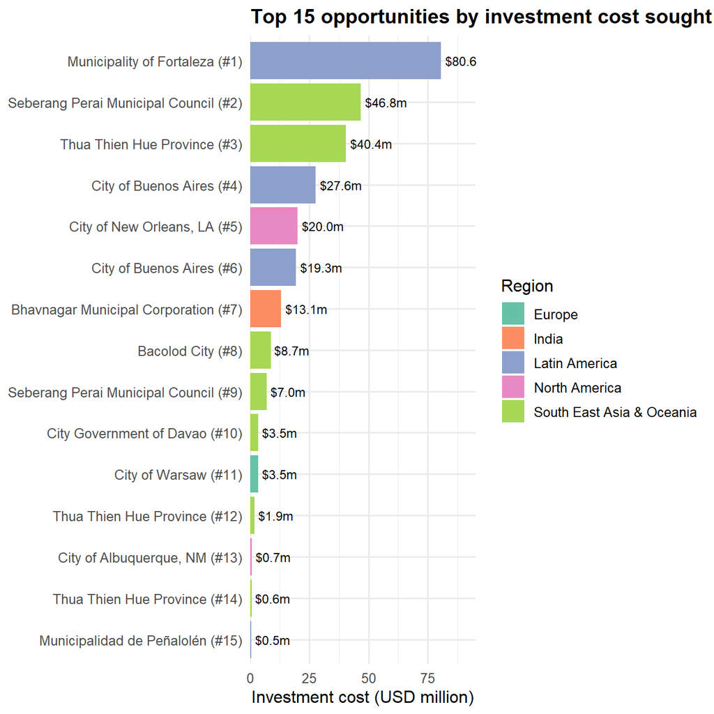

```r
ranked |>
  slice_head(n = 15) |>
  mutate(label = paste0(City, " (#", Rank, ")")) |>
  ggplot(aes(x = `Investment cost (USD)` / 1e6, y = reorder(label, `Investment cost (USD)`), fill = Region)) +
  geom_col() +
  geom_text(aes(label = paste0("$", comma(`Investment cost (USD)` / 1e6, accuracy = 0.1), "m")), hjust = -0.1, size = 3.2) +
  scale_x_continuous(expand = expansion(mult = c(0, 0.18))) +
  scale_fill_brewer(palette = "Set2") +
  labs(title = "Top 15 opportunities by investment cost sought",
       x = "Investment cost (USD million)", y = NULL)
```

**Findings:** There are 20 projects on the final list. The largest opportunities are in Municipality of Fortaleza (about USD 81 million), Seberang Perai Municipal Council and Thua Thien Hue Province. Costs fall quickly down the ranking, so a small number of projects account for most of the money. For each of the top projects the firm should still do normal due diligence, because a high rank only means a large cost, not a good return. Note also that 2 of the ranked projects are wastewater systems that the city labelled as waste management; a water-treatment project may not match the firm’s waste expertise, so these should be confirmed. The “Cost check” column flags 3 ranked project(s) whose investment cost is larger than the stated total cost.

## 5.4 Manual-review list: waste-related projects outside the waste sector

These projects pass the other three rules (business collaboration, loan or PPP funding, known cost) and mention waste-related words, but the city did not label them as waste management. They are not part of the ranked list above.

```r
keyword_list <- projects |>
  filter(is_project, waste_keyword_only, business_collab, loan_or_ppp, investment_clean > 0) |>
  arrange(desc(investment_clean)) |>
  transmute(Rank = row_number(), City = cityname, Region = cityregion,
            `Project type` = project_type,
            Project = str_trunc(str_squish(project_info), 110),
            `Investment cost (USD)` = investment_clean)

kable(keyword_list, format.args = list(big.mark = ",", scientific = FALSE),
      caption = "Waste-related projects outside the waste sector (for manual review, not ranked)")
```

Waste-related projects outside the waste sector (for manual review, not ranked)

| Rank | City | Region | Project type | Project | Investment cost (USD) |
| --- | --- | --- | --- | --- | --- |
| 1 | City of Paris | Europe | Other | Other: Many project areas : building, mobility, energy, air quality, circular economy, etc. - Climate and S… | 339,047,503.38 |
| 2 | Thua Thien Hue Province | South East Asia & Oceania | Other | Other: Secondary Cities Development Program - The Secondary Cities Development Program (Green Cities) is an… | 92,650,586.92 |
| 3 | City of Warsaw | Europe | Renewable energy | Renewable energy - Development of municipal biogas plants: Installation of organic recycling by digestion o… | 70,464,177.63 |
| 4 | Seberang Perai Municipal Council | South East Asia & Oceania | Renewable energy | Renewable energy - Waste To Energy: Landfill Gas Mining | 23,379,204.08 |
| 5 | City of Indianapolis, IN | North America | Renewable energy | Renewable energy - Brightfield development on a municipally owned closed landfil: Office of Sustainability … | 10,000,000.00 |
| 6 | Municipio de Mérida | Latin America | Nature | Nature-Based Solutions - Urban Storm Drainage Systems The implementation of Sustainable Urban Storm Drainag… | 987,632.17 |
| 7 | City of Yokohama | Japan | Other | Other: Achieve regional requirements such as “virtually zero CO2 emissions from electricity consumption in … | 668,746.13 |
| 8 | Municipalidad de Peñalolén | Latin America | Buildings | Buildings - Sustainable public buildings - water: The sustainable municipal buildings project is linked to … | 105,395.62 |
| 9 | Renca | Latin America | Public and green spaces | Public and green spaces - Mapocho River Biological Corridor / Mapocho river recovery: Resilient Maipo, rive… | 52,697.81 |
| 10 | Municipalidad de Córdoba | Latin America | Public and green spaces | Public and green spaces - Remediation of Parque Sarmiento Lagoon - City of Córdoba with Ozone Nanobubbles (… | 12,239.65 |
| 11 | Municipalidad de Peñalolén | Latin America | Other | Other: Citizen participation and climate empowerment - Climate Democracy Accelerator: It is an initiative o… | 10,539.56 |

**Findings:** There are 11 such projects, worth about USD 537 million in total. If they were mixed into the main ranking they would make up 66% of the combined value, and the largest, in City of Paris, would be ranked first. Some of these (for example landfill gas or biogas) are genuinely waste-related, but others are broad multi-sector programmes where waste is only a small part, so an analyst should read the full project descriptions before treating any of them as an opportunity for a waste-focused firm.

## 5.5 What I left out (sensitivity checks)

```r
base_ok <- projects$is_project & projects$business_collab & projects$loan_or_ppp & (projects$investment_clean > 0) %in% TRUE
rule_sensitivity <- tibble(
  Scenario = c("Base case",
               "Include wastewater projects",
               "Doesn't require business collaboration",
               "Doesn't require loan/ PPP funding model",
               "Waste projects meeting rules 1-3 but with no cost reported (watch list)",
               "Also accept waste keywords outside the waste sector (see manual-review list)"),
  Projects = c(
    sum(base_ok & projects$is_waste),
    sum(base_ok & (projects$is_waste | str_detect(projects$info_lower, "wastewater|waste water") %in% TRUE)),
    sum(projects$is_project & projects$is_waste & projects$loan_or_ppp & (projects$investment_clean > 0) %in% TRUE),
    sum(projects$is_project & projects$is_waste & projects$business_collab & (projects$investment_clean > 0) %in% TRUE),
    sum(projects$is_project & projects$is_waste & projects$business_collab & projects$loan_or_ppp & !((projects$investment_clean > 0) %in% TRUE)),
    sum(base_ok & (projects$is_waste | projects$waste_keyword_only))
  )
)
kable(rule_sensitivity, caption = "How the list changes if I relax or change a rule")
```

How the list changes if I relax or change a rule

| Scenario | Projects |
| --- | --- |
| Base case | 20 |
| Include wastewater projects | 24 |
| Doesn’t require business collaboration | 54 |
| Doesn’t require loan/ PPP funding model | 50 |
| Waste projects meeting rules 1-3 but with no cost reported (watch list) | 14 |
| Also accept waste keywords outside the waste sector (see manual-review list) | 31 |

**Findings:** The list is sensitive to the business rules. Relaxing the collaboration rule or the funding-model rule would increase the list from 20 to 54 or 50 projects, accepting waste keywords outside the waste sector would add 11 (mostly broad programmes; see the manual-review list), and adding wastewater projects from other sectors adds 4. The firm can therefore widen the search if it needs more deal flow. I also note a watch list of projects that satisfy the other rules but have no cost reported; the firm could contact those cities to ask for the missing cost information.

## 5.6 Supporting analysis: what drives project investment cost? (linear regression)

The ranking is by cost, so I want to understand what makes projects expensive. Cost is extremely right-skewed, so I model the log (base 10) of the investment cost. That way a coefficient can be read as a multiplication of cost. I use cleaned positive costs from all projects (not only waste projects) to have enough data.

```r
lm_df <- projects |>
  filter(is_project, investment_clean > 0) |>
  mutate(log_cost = log10(investment_clean),
         log_pop  = log10(area_population),
         log_gdp  = log10(econ_gdpt),
         type_grp = fct_lump_n(factor(replace_na(project_type, "Unknown")), n = 6, other_level = "Other types"),
         type_grp = fct_relevel(type_grp, "Other types"),
         region   = fct_relevel(factor(cityregion), "Europe"),
         business_collab = factor(if_else(business_collab, "Yes", "Not confirmed")),
         business_collab = fct_relevel(business_collab, "Not confirmed")) |>
  filter(!is.na(log_pop), !is.na(log_gdp))

cat("Observations used in the regression:", nrow(lm_df), "\n")
```

```
## Observations used in the regression: 1333
```

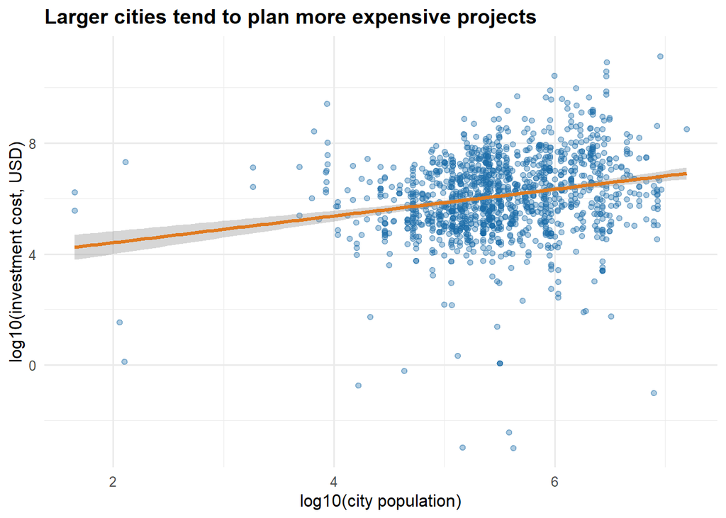

```r
ggplot(lm_df, aes(x = log_pop, y = log_cost)) +
  geom_point(alpha = 0.35, colour = col_main) +
  geom_smooth(method = "lm", colour = col_accent, se = TRUE) +
  labs(title = "Larger cities tend to plan more expensive projects",
       x = "log10(city population)", y = "log10(investment cost, USD)")
```

```r
lm_fit <- lm(log_cost ~ log_pop + log_gdp + region + type_grp + business_collab, data = lm_df)

lm_tidy <- broom::tidy(lm_fit, conf.int = TRUE)
lm_tidy |>
  mutate(`cost multiplier` = 10^estimate) |>
  select(term, estimate, std.error, p.value, `cost multiplier`) |>
  kable(digits = 3, caption = "Linear regression of log10(investment cost)")
```

Linear regression of log10(investment cost)

| term | estimate | std.error | p.value | cost multiplier |
| --- | --- | --- | --- | --- |
| (Intercept) | -1.369 | 1.112 | 0.219 | 0.043 |
| log_pop | 0.503 | 0.057 | 0.000 | 3.181 |
| log_gdp | 0.386 | 0.091 | 0.000 | 2.435 |
| regionIndia | -1.285 | 0.360 | 0.000 | 0.052 |
| regionJapan | -0.700 | 0.675 | 0.300 | 0.200 |
| regionLatin America | -0.818 | 0.128 | 0.000 | 0.152 |
| regionNorth America | -0.338 | 0.185 | 0.067 | 0.459 |
| regionSouth East Asia & Oceania | -0.410 | 0.140 | 0.003 | 0.389 |
| regionUKWW | -0.410 | 0.134 | 0.002 | 0.389 |
| type_grpBuildings | 0.420 | 0.137 | 0.002 | 2.631 |
| type_grpOther | 0.321 | 0.127 | 0.012 | 2.092 |
| type_grpRenewable energy | 0.273 | 0.119 | 0.022 | 1.874 |
| type_grpTransport | 0.600 | 0.119 | 0.000 | 3.980 |
| type_grpWaste management (including waste recycling) | 0.060 | 0.123 | 0.623 | 1.149 |
| type_grpWater management | 0.195 | 0.139 | 0.161 | 1.566 |
| business_collabYes | 0.382 | 0.078 | 0.000 | 2.413 |

```r
broom::glance(lm_fit) |> select(r.squared, adj.r.squared, sigma, df, nobs) |> kable(digits = 3)
```

| r.squared | adj.r.squared | sigma | df | nobs |
| --- | --- | --- | --- | --- |
| 0.182 | 0.173 | 1.321 | 15 | 1333 |

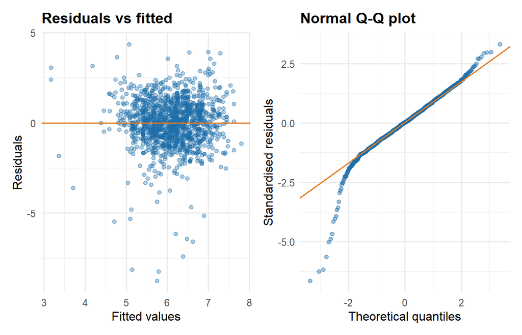

```r
aug <- broom::augment(lm_fit)

d1 <- ggplot(aug, aes(.fitted, .resid)) +
  geom_point(alpha = 0.35, colour = col_main) +
  geom_hline(yintercept = 0, colour = col_accent) +
  labs(title = "Residuals vs fitted", x = "Fitted values", y = "Residuals")

d2 <- ggplot(aug, aes(sample = .std.resid)) +
  stat_qq(alpha = 0.4, colour = col_main) + stat_qq_line(colour = col_accent) +
  labs(title = "Normal Q-Q plot", x = "Theoretical quantiles", y = "Standardised residuals")

d1 + d2
```

**Findings:** The log-log relationship between population and cost is positive, so larger cities plan bigger projects. In the regression, each coefficient shows how many “powers of ten” the cost changes when the variable increases by one unit while the others are held fixed; the *cost multiplier* column converts this into a plain multiple (for example 2 means about twice the cost). In my output, population and national GDP both have positive, highly significant effects (a ten-times larger city is associated with roughly 3 times higher project cost, since 10^0.5 is about 3.2). Compared with Europe (the reference region), projects in India and Latin America are much cheaper (about 5% and 15% of the European cost, holding other things equal), transport projects are about four times more expensive than the “other types” group, and cities with confirmed business collaboration plan projects roughly 2.4 times larger. Waste management projects are *not* significantly more or less expensive than the reference group. The R-squared is modest (about 0.18), which tells me that city size, national income, region and project type explain only part of the variation in project cost; much of the cost depends on the specific project. The diagnostic plots are reasonably acceptable after the log transformation: there is no strong funnel shape in the residuals, and the Q-Q plot follows the line apart from some tail departures. I therefore use this model to describe what is associated with cost and not to predict costs of single projects. Note that the regression shows association and not causation.

# 6 Part 4: Predicting environmental controversy risk

## 6.1 Understanding the business problem

Ultimate goal is to build a classification model that predicts whether a firm is involved in an environmental controversy (`env_contro = Yes`). The model is for initial screening: firms flagged as high risk will be reviewed by experts.

**Judgement:**

- Only about 2.8% of firms are positives, so a model that says “No controversy” for everybody would be 97% accurate and completely useless. Accuracy is therefore not a good metric here.
- The scenario says false positives are relatively cheap but **false negatives are costly** (a risky firm slips through). So I care most about **sensitivity (recall)**: the share of truly controversial firms that we catch.
- I will still watch precision and the share of firms flagged, because experts have limited time.
- To compare models fairly without choosing a threshold I use ROC AUC and PR AUC (area under the precision-recall curve; this is more informative than ROC AUC when positives are rare). Then I choose the final decision threshold separately, using the F2 score, which weights recall more heavily than precision.

## 6.2 Data preparation

### 6.2.1 Feature engineering and the train / test split

Steps followed:

1. **Create ratio features.** Raw emissions, energy and capital expenditure mostly reflect firm *size*. Dividing by revenue or assets (intensity) tells me whether the firm is *inefficient for its size*.
2. **Split the data first** into a training set (75%) and a test set (25%), stratified by the outcome so both sets keep about 2.8% positives. The test set stays untouched until the very end, to give an honest estimate of performance on new firms.
3. **Learn all pre-processing rules (medians, transformations, scaling) from the training set only**, then apply the same rules to the test set, so no information from the test set leaks into the model.

I build the whole machine-learning workflow with **base R and a few classic packages** (`rpart`, `glmnet`, `pROC`, `class`). This is a transparent way to see exactly what happens in each step, and it needs no extra modelling framework.

```r
firm_df <- firms |>
  mutate(co2_intensity    = if_else(fin_rev > 0,   (env_co2s1 + env_co2s2) / fin_rev, NA_real_),
         energy_intensity = if_else(fin_rev > 0,   env_energy / fin_rev,              NA_real_),
         capex_intensity  = if_else(fin_asset > 0, fin_capex / fin_asset,             NA_real_))
```

```r
split_idx <- unlist(lapply(split(seq_len(nrow(firm_df)), firm_df$env_contro),
                           function(i) sample(i, round(0.75 * length(i)))))
train <- firm_df[sort(split_idx), ]
test  <- firm_df[-split_idx, ]
```

Both sets keep the same share of controversial firms (stratified split)

| set | firms | controversies | share |
| --- | --- | --- | --- |
| Training | 5456 | 154 | 2.82% |
| Test | 1819 | 52 | 2.86% |

**Findings:** the stratified split keeps the same class balance in both sets. The test set has only 52 controversial firms, so test results will be noisy and I will report an uncertainty range later.

### 6.2.2 Pre-processing rules

1. Missing-value indicators: Missing emissions or cost data often means “not disclosed”, which could itself be a signal
2. Median imputation: Logistic regression and KNN cannot handle missing values. The median is robust to outliers.
3. Yeo-Johnson transformation: Financial and emission variables are extremely right-skewed, and some (ROE, revenue) contain negative values, so a log transform would fail. Yeo-Johnson handles negatives. I estimate its parameter (lambda) by maximum likelihood.
4. Standardisation (mean 0, sd 1): KNN uses distances, and PCA and penalised regression work better when variables are on the same scale.

5.Lump rare categories: Industry has 59 levels and headquarters country has 63; I keep categories with at least 1% of training firms and group the rest as “other”.

6. Dummy variables: Models need numbers, not text categories.
7. Drop zero-variance columns: A column that never changes carries no information.

I write the pre-processing as two functions: `learn_prep()` learns the rules from a data set, and `apply_prep()` applies them to any data.

```r
cont_vars <- c("env_score", "env_co2s1", "env_co2s2", "env_co2s3", "env_energy", "fin_asset", "fin_rev", "fin_cor", "fin_capex", "fin_roa", "fin_roe", "fin_ebitda", "fin_cr", "fin_dte", "marketcap","co2_intensity", "energy_intensity", "capex_intensity")

na_vars  <- c("env_co2s1", "env_co2s2", "env_co2s3", "env_energy", "fin_cor", "fin_cr")

bin_vars <- c("pol_climate", "pol_energy", "pol_envsup", "pol_bio", "pol_socsup", "env_product")

# Yeo-Johnson transformation (works for negative values too)
yj_trans <- function(x, lambda) {
  out <- numeric(length(x)); pos <- x >= 0
  out[pos]  <- if (abs(lambda) > 1e-8) ((x[pos] + 1)^lambda - 1) / lambda else log1p(x[pos])
  out[!pos] <- if (abs(lambda - 2) > 1e-8) -((-x[!pos] + 1)^(2 - lambda) - 1) / (2 - lambda) else -log1p(-x[!pos])
  out
}

# choose lambda by maximum likelihood (same idea as step_YeoJohnson in tidymodels)
yj_lambda <- function(x) {
  suppressWarnings(optimize(function(l) -length(x) / 2 * log(var(yj_trans(x, l))) + (l - 1) * sum(sign(x) * log1p(abs(x))),
           interval = c(-5, 5), maximum = TRUE))$maximum
}

# step 1: LEARN the pre-processing rules from a training set only
learn_prep <- function(d) {
  p <- list()
  p$median <- map_dbl(d[cont_vars], median, na.rm = TRUE)
  imputed  <- map2(d[cont_vars], p$median, ~ replace(.x, is.na(.x), .y))
  p$lambda <- map_dbl(imputed, function(x) { l <- yj_lambda(x); if (is.finite(l)) l else 0 })
  trans    <- map2(imputed, p$lambda, yj_trans)

  # safety net: if a transformed variable has Inf/NaN or no spread, use lambda = 0 (log-type transform) instead
  bad <- !map_lgl(trans, ~ all(is.finite(.x)) && isTRUE(sd(.x) > 0))
  p$lambda[bad] <- 0
  trans[bad]    <- map2(imputed[bad], p$lambda[bad], yj_trans)
  p$fallback    <- names(which(bad))

  p$mean <- map_dbl(trans, mean)
  p$sd   <- map_dbl(trans, sd)
  keep_levels <- function(v) names(which(prop.table(table(d[[v]])) >= 0.01))
  p$industry_keep <- keep_levels("industry")
  p$hq_keep       <- keep_levels("firm_hq")
  p$zv <- character(0)
  p$zv <- names(which(map_dbl(select(apply_prep(d, p), -env_contro), sd) == 0))
  p
}

# step 2: APPLY the learned rules to any data (training, validation fold or test)
apply_prep <- function(d, p) {
  out <- tibble(.rows = nrow(d))
  for (v in na_vars) out[[paste0("na_ind_", v)]] <- as.integer(is.na(d[[v]]))
  for (v in cont_vars) {
    x <- d[[v]]; x[is.na(x)] <- p$median[[v]]
    out[[v]] <- (yj_trans(x, p$lambda[[v]]) - p$mean[[v]]) / p$sd[[v]]
  }
  for (v in bin_vars) out[[v]] <- d[[v]]
  ind <- if_else(d$industry %in% p$industry_keep, d$industry, "other")
  hq  <- if_else(d$firm_hq  %in% p$hq_keep,       d$firm_hq,  "other")
  for (lv in setdiff(c(sort(p$industry_keep), "other"), sort(p$industry_keep)[1]))
    out[[make.names(paste0("industry_", lv))]] <- as.integer(ind == lv)
  for (lv in setdiff(c(sort(p$hq_keep), "other"), sort(p$hq_keep)[1]))
    out[[make.names(paste0("hq_", lv))]] <- as.integer(hq == lv)
  out <- out[, setdiff(names(out), p$zv), drop = FALSE]
  out$env_contro <- d$env_contro
  out
}

prep_obj    <- learn_prep(train)
train_baked <- apply_prep(train, prep_obj)
test_baked  <- apply_prep(test,  prep_obj)

prep_obj$fallback   # which variables needed the fallback (probably "fin_asset")
```

```
## character(0)
```

```r
sum(is.na(train_baked)) # must be 0
```

```
## [1] 0
```

```r
cat("Predictors after pre-processing:", ncol(train_baked) - 1, "\n")
```

```
## Predictors after pre-processing: 85
```

## 6.3 Exploratory data analysis and bivariate analysis (training data only)

I explore only the training data so that the test set stays unseen.

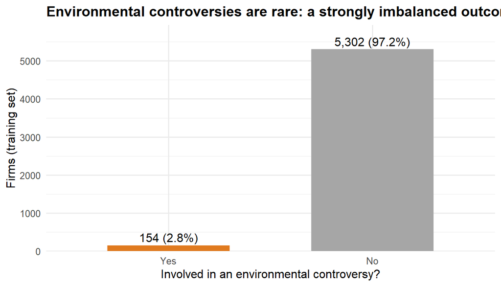

```r
train |>
  count(env_contro) |>
  mutate(share = n / sum(n)) |>
  ggplot(aes(x = env_contro, y = n, fill = env_contro)) +
  geom_col(show.legend = FALSE, width = 0.6) +
  geom_text(aes(label = paste0(comma(n), " (", percent(share, accuracy = 0.1), ")")), vjust = -0.4) +
  scale_fill_manual(values = c(Yes = col_accent, No = col_grey)) +
  scale_y_continuous(expand = expansion(mult = c(0, 0.12))) +
  labs(title = "Environmental controversies are rare: a strongly imbalanced outcome",
       x = "Involved in an environmental controversy?", y = "Firms (training set)")
```

**Findings:** about 97% of firms have no controversy. Any model must handle this imbalance, otherwise it will simply predict “No” for everyone.

### 6.3.1 Industry and country

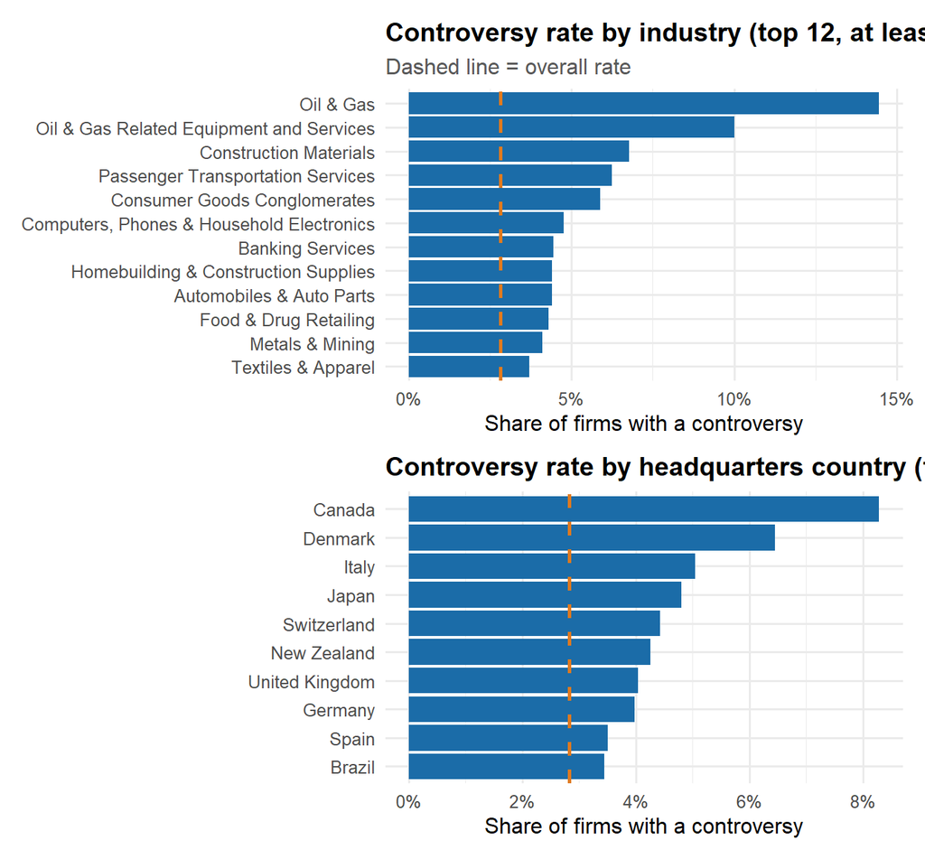

```r
base_rate <- mean(train$env_contro == "Yes")

ind_tbl <- train |>
  group_by(industry) |>
  summarise(firms = n(), rate = mean(env_contro == "Yes"), .groups = "drop") |>
  filter(firms >= 30) |>
  slice_max(rate, n = 12)

hq_tbl <- train |>
  group_by(firm_hq) |>
  summarise(firms = n(), rate = mean(env_contro == "Yes"), .groups = "drop") |>
  filter(firms >= 30) |>
  slice_max(rate, n = 10)

pi <- ggplot(ind_tbl, aes(x = rate, y = reorder(industry, rate))) +
  geom_col(fill = col_main) +
  geom_vline(xintercept = base_rate, colour = col_accent, linetype = "dashed", linewidth = 1) +
  scale_x_continuous(labels = percent) +
  labs(title = "Controversy rate by industry (top 12, at least 30 firms)",
       subtitle = "Dashed line = overall rate", x = "Share of firms with a controversy", y = NULL)

ph <- ggplot(hq_tbl, aes(x = rate, y = reorder(firm_hq, rate))) +
  geom_col(fill = col_main) +
  geom_vline(xintercept = base_rate, colour = col_accent, linetype = "dashed", linewidth = 1) +
  scale_x_continuous(labels = percent) +
  labs(title = "Controversy rate by headquarters country (top 10, at least 30 firms)",
       x = "Share of firms with a controversy", y = NULL)

wrap_plots(pi, ph, ncol = 1)
```

**Findings:** controversy rates are clearly higher in resource-heavy industries (oil and gas and related services are far above average) and in some countries. This is a strong sign that industry and country carry predictive information, which is why I keep them (grouped) in the model.

### 6.3.2 Numeric variables by outcome (distributions and tests)

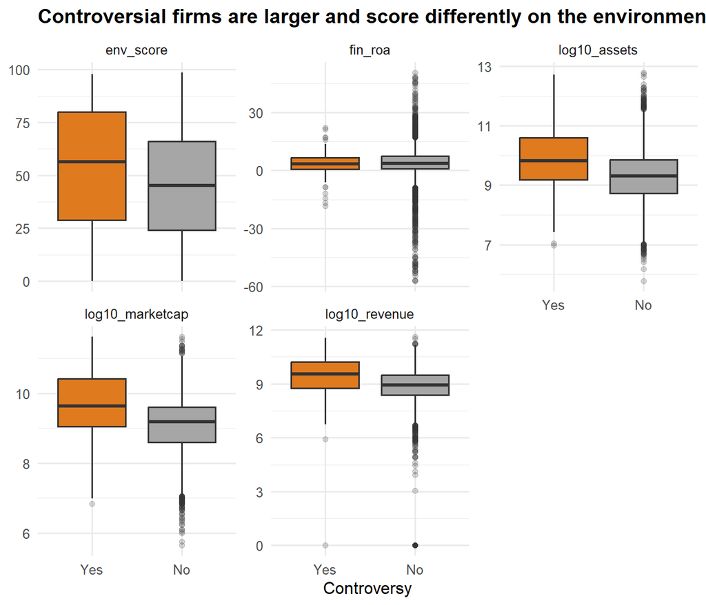

```r
eda_long <- train |>
  mutate(log10_marketcap = log10(marketcap + 1), log10_assets = log10(fin_asset + 1),
         log10_revenue = log10(pmax(fin_rev, 0) + 1)) |>
  select(env_contro, env_score, log10_marketcap, log10_assets, log10_revenue, fin_roa) |>
  pivot_longer(-env_contro, names_to = "variable", values_to = "value") |>
  filter(!is.na(value), !(variable == "fin_roa" & abs(value) > 60))     # trim extreme ROA for readability only

ggplot(eda_long, aes(x = env_contro, y = value, fill = env_contro)) +
  geom_boxplot(show.legend = FALSE, outlier.alpha = 0.2) +
  scale_fill_manual(values = c(Yes = col_accent, No = col_grey)) +
  facet_wrap(~ variable, scales = "free_y") +
  labs(title = "Controversial firms are larger and score differently on the environmental pillar",
       x = "Controversy", y = NULL)
```

```r
test_vars <- c("env_score", "env_product", "marketcap", "fin_asset", "fin_rev", "fin_roa", "fin_roe", "fin_ebitda", "fin_dte", "env_co2s1", "env_energy", "co2_intensity")

num_tests <- map_dfr(test_vars, function(v) {
  x <- train[[v]]; y <- train$env_contro
  tibble(variable = v,
         median_controversy = median(x[y == "Yes"], na.rm = TRUE),
         median_no_controversy = median(x[y == "No"], na.rm = TRUE),
         p_wilcoxon = wilcox.test(x ~ y)$p.value)
}) |>
  mutate(significant_5pct = if_else(p_wilcoxon < 0.05, "Yes", "No")) |>
  arrange(p_wilcoxon)

kable(num_tests, digits = c(0, 3, 3, 4, 0), format.args = list(big.mark = ",", scientific = FALSE),
      caption = "Wilcoxon rank-sum tests: do controversial and non-controversial firms differ?")
```

Wilcoxon rank-sum tests: do controversial and non-controversial firms differ?

| variable | median_controversy | median_no_controversy | p_wilcoxon | significant_5pct |
| --- | --- | --- | --- | --- |
| marketcap | 4,330,945,758.378 | 1,529,572,232.726 | 0.0000 | Yes |
| fin_rev | 3,409,724,068.955 | 875,462,414.205 | 0.0000 | Yes |
| env_co2s1 | 98,095.000 | 7,872.000 | 0.0000 | Yes |
| fin_asset | 6,694,656,039.341 | 1,988,318,751.419 | 0.0000 | Yes |
| env_energy | 3,457,440.000 | 459,288.000 | 0.0000 | Yes |
| env_score | 56.489 | 45.193 | 0.0000 | Yes |
| fin_dte | 0.360 | 0.185 | 0.0013 | Yes |
| co2_intensity | 0.000 | 0.000 | 0.0314 | Yes |
| fin_ebitda | 16.902 | 16.551 | 0.0832 | No |
| fin_roe | 9.469 | 8.776 | 0.2851 | No |
| env_product | 0.000 | 0.000 | 0.3774 | No |
| fin_roa | 3.496 | 3.687 | 0.7578 | No |

```r
# Welch t-test on log market capitalisation (log makes it closer to normal)
t.test(log10(marketcap + 1) ~ env_contro, data = train)
```

```
##
##  Welch Two Sample t-test
##
## data:  log10(marketcap + 1) by env_contro
## t = 5.9639, df = 158.9, p-value = 1.543e-08
## alternative hypothesis: true difference in means between group Yes and group No is not equal to 0
## 95 percent confidence interval:
##  0.3257839 0.6483882
## sample estimates:
## mean in group Yes  mean in group No
##          9.573644          9.086558
```

**Findings:** I use the Wilcoxon test because these variables are very skewed and have outliers. Variables with small p-values (typically firm size measures such as market capitalisation, assets and revenue, and emissions) differ significantly between the two groups: controversial firms tend to be bigger and higher-emitting. The Welch t-test on log market capitalisation confirms the size difference. Remember that statistical significance only tells me a difference exists, not that it is large enough to predict well on its own.

### 6.3.3 Policies and controversy

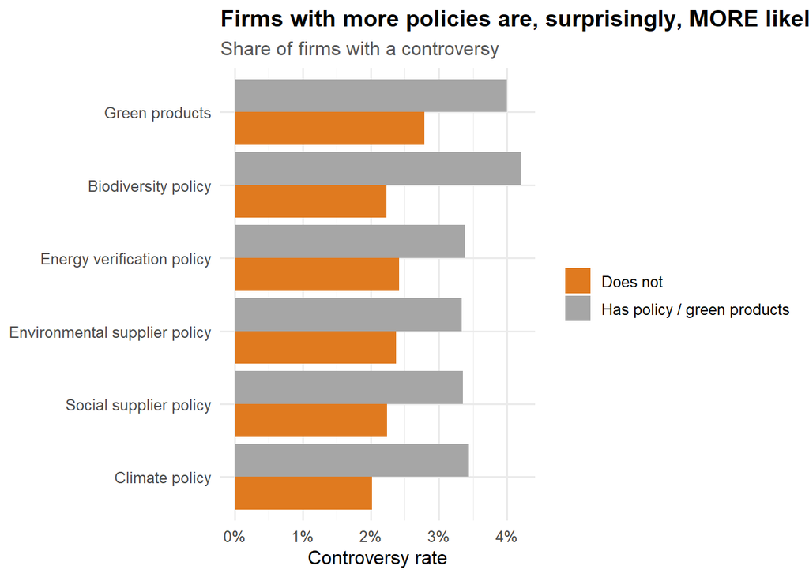

```r
pol_vars <- c(pol_climate = "Climate policy", pol_energy = "Energy verification policy",pol_envsup = "Environmental supplier policy", pol_bio = "Biodiversity policy", pol_socsup = "Social supplier policy", env_product = "Green products")

pol_tbl <- map_dfr(names(pol_vars), function(v) {
  tab <- table(train[[v]], train$env_contro)
  tibble(policy = pol_vars[[v]],
         rate_with = tab["1", "Yes"] / sum(tab["1", ]),
         rate_without = tab["0", "Yes"] / sum(tab["0", ]),
         p_chisq = suppressWarnings(chisq.test(tab)$p.value))
})

pol_tbl |>
  pivot_longer(c(rate_with, rate_without), names_to = "has_policy", values_to = "rate") |>
  mutate(has_policy = recode(has_policy, rate_with = "Has policy / green products", rate_without = "Does not")) |>
  ggplot(aes(x = rate, y = reorder(policy, rate), fill = has_policy)) +
  geom_col(position = "dodge") +
  scale_x_continuous(labels = percent) +
  scale_fill_manual(values = c(col_accent, col_grey)) +
  labs(title = "Firms with more policies are, surprisingly, MORE likely to have controversies",
       subtitle = "Share of firms with a controversy",
       x = "Controversy rate", y = NULL, fill = NULL)
```

```r
pol_tbl |> mutate(across(starts_with("rate"), ~ percent(.x, accuracy = 0.1)), p_chisq = round(p_chisq, 4)) |>
  kable(caption = "Chi-squared tests of independence between each policy and controversy")
```

Chi-squared tests of independence between each policy and controversy

| policy | rate_with | rate_without | p_chisq |
| --- | --- | --- | --- |
| Climate policy | 3.4% | 2.0% | 0.0022 |
| Energy verification policy | 3.4% | 2.4% | 0.0405 |
| Environmental supplier policy | 3.3% | 2.4% | 0.0406 |
| Biodiversity policy | 4.2% | 2.2% | 0.0001 |
| Social supplier policy | 3.4% | 2.2% | 0.0160 |
| Green products | 4.0% | 2.8% | 0.5268 |

**Findings:** The direction may look counter-intuitive: firms that have environmental policies show a higher controversy rate. I think this is not because policies cause controversies. Instead, large firms are more likely to both publish policies and attract media attention.

Chi-squared tests show which differences are statistically significant: in my output every policy difference is significant at the 5% level except the share of green products. This is an important reminder that the model finds associations, so it should be used for screening and not for blaming firms.